# COOP

Brian

7/27/2022

# Disclaimer

*This work is very preliminary as I get back into the coding swing of things. Data wrangling and figure generation will be done via R, but the rest of the project will be done using good ol’ microsoft products. This is just an entry point into data crunching and should by no means be considered a final product.*

# Coop Data

NOAA/NWS Cooperative Observer Network

Two stations near steamboat, according to this [site](https://wrcc.dri.edu/inventory/coop05.html). 057936 02 SBTC2 UNITED STATES CO ROUTT +7 STEAMBOAT SPRINGS 40 30 17 -106 51 58 6636 057942 02 SSPC2 UNITED STATES CO ROUTT +7 STEAMBOAT SPRINGS 1 W 40 29 00 -106 51 00 6700

Downloading from the [Iowa Environmental Mesonet](https://mesonet.agron.iastate.edu/request/coop/fe.phtml?network=COCLIMATE). NOAA package not working, maybe due to user error.

### Data Cleaning

```r
coop_steamboat_clean <- read.csv("C:/Users/bsteen/OneDrive - Colostate/Documents/MS_Research/research-COOP/data_clean/coop_steamboat_clean.csv", header = TRUE)
```

### Figure check

```r
coop_steamboat_clean$Date <- ymd(coop_steamboat_clean$Date)

str(coop_steamboat_clean)
```

```
## 'data.frame':    44740 obs. of  13 variables:
##  $ station     : chr  "CO7936" "CO7936" "CO7936" "CO7936" ...
##  $ station_name: chr  "STEAMBOAT SPRINGS" "STEAMBOAT SPRINGS" "STEAMBOAT SPRINGS" "STEAMBOAT SPRINGS" ...
##  $ lat         : num  40.5 40.5 40.5 40.5 40.5 ...
##  $ lon         : num  -107 -107 -107 -107 -107 ...
##  $ day         : chr  "1/1/1900" "1/2/1900" "1/3/1900" "1/4/1900" ...
##  $ doy         : int  1 2 3 4 5 6 7 8 9 10 ...
##  $ max_T_c     : num  -5.6 -0.6 5 7.8 3.3 4.4 -1.7 0.6 0.6 0.6 ...
##  $ min_T_c     : num  -21.1 -17.8 -6.1 -5.6 -10.6 -9.4 -18.9 -15.6 -15 -18.9 ...
##  $ avg_T_c     : num  -13.35 -9.2 -0.55 1.1 -3.65 ...
##  $ Date        : Date, format: "1900-01-01" "1900-01-02" ...
##  $ waterYear   : int  1900 1900 1900 1900 1900 1900 1900 1900 1900 1900 ...
##  $ daymonth    : chr  "01-01" "02-01" "03-01" "04-01" ...
##  $ waterDay    : int  93 94 95 96 97 98 99 100 101 102 ...
```

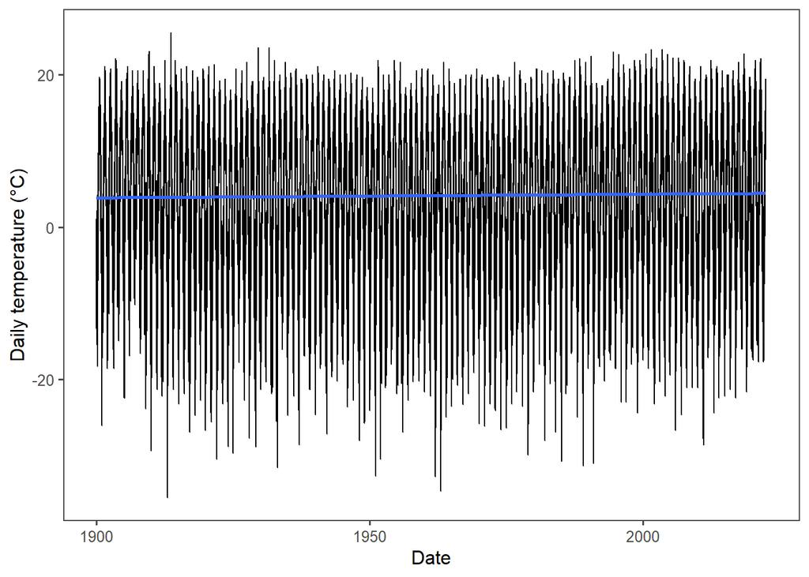

```r
ggplot(coop_steamboat_clean, aes(x = Date, y = avg_T_c)) +
  geom_line() + #lwd = 2) +
  theme_few() +
  geom_smooth(method = "lm", se=FALSE) +
  ylab('Daily temperature (°C)') +
  xlab('Date')
```

```r
#Check for outliers....

#dygraph

COOP_temp_xts <- xts(coop_steamboat_clean$avg_T_c, order.by = coop_steamboat_clean$Date)

dygraph(COOP_temp_xts) %>%
  dyAxis("y", label = "Daily temperature (°C)")
```

[interactive chart not shown]

## Detrending Data

```r
#SF figured out the yearly average by water year

#average water year temperature

COOP_yearly_wy_aver <- coop_steamboat_clean %>%
  group_by(waterYear) %>%
  mutate(aver_ann_temp = mean(avg_T_c))
```

```r
#Average temperature by day for all water years:

COOP_daily_wy_aver <- COOP_yearly_wy_aver %>%
  group_by(daymonth) %>%
  mutate(aver_day_temp = mean(aver_ann_temp))

#average mean temperature by day for the period of record:

COOP_daily_wy_aver <- COOP_daily_wy_aver %>%
  group_by(daymonth) %>%
  mutate(all_ave_temp = mean(COOP_daily_wy_aver$aver_day_temp))

#str(daily_wy_aver)
```

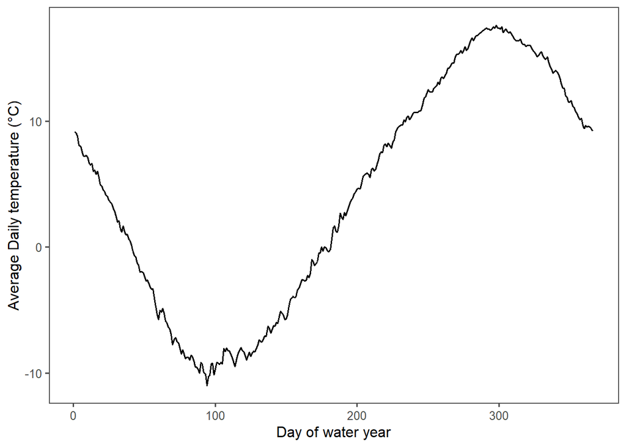

```r
# try to show all years as means.
COOP_daily_wy_aver2 <- COOP_daily_wy_aver %>%
  #filter(waterYear == "1987" | waterYear == "2021") %>%
  group_by(waterDay) %>%
  mutate(date_temp = mean(avg_T_c))

COOP_daily_wy_aver2$date_temp <- signif(COOP_daily_wy_aver2$date_temp,3) #reduce the sig figs

ggplot(COOP_daily_wy_aver2, aes(x = waterDay, y = date_temp))+#, color = waterYear)) +
  geom_line(size= 0.7) +
  #geom_line(aes) +
  theme_few() +
  #geom_smooth(method = "lm", se=FALSE) +
  ylab('Average Daily temperature (°C)') +
  xlab('Day of water year')
```

# Standard Deviation

To figure out the standard deviation for each year, I want the “residual” for each daily value.

The standard deviation will be the daily residual minus the mean of the residuals by water year, summed and squared, then divided by the number of observations minus one. The square root of the resulting value of which is thus the standard deviation for the water year.

Determining residuals

```r
COOP_standard_dev <- COOP_daily_wy_aver %>%
  group_by(waterYear) %>%
  mutate(residual = (all_ave_temp-aver_ann_temp)+avg_T_c-aver_day_temp) %>%
  mutate(deviation = abs(residual-lag(residual)))

mean(COOP_standard_dev$residual)
```

```
## [1] 1.437375e-16
```

*The mean of the residuals is close enough to zero*

Calculating standard deviation for the timeseries

```r
COOP_standard_dev_all <- COOP_standard_dev %>%
  group_by(waterYear) %>%
  mutate(nmbr = n())

COOP_standard_dev_all <- COOP_standard_dev_all %>%
  group_by(waterYear) %>%
  mutate(resid_mean = mean(residual)) %>%
  mutate(sd_1 = residual-resid_mean) %>%
  mutate(sd_2 = (((sum((sd_1)^2))/((nmbr-1))))^(0.5)) %>%
  distinct(sd_2, .keep_all = TRUE) %>%
   select(waterYear, sd_2)

COOP_standard_dev_all %>%
  kable(.,'html') %>%
  kable_styling() %>%
  scroll_box(width='250px',height='500px')
```

| waterYear | sd_2 |
| --- | --- |
| 1900 | 9.165729 |
| 1901 | 9.465607 |
| 1902 | 9.168378 |
| 1903 | 9.405604 |
| 1904 | 8.121802 |
| 1905 | 9.122414 |
| 1906 | 9.316892 |
| 1907 | 7.205865 |
| 1908 | 9.151984 |
| 1909 | 10.615855 |
| 1910 | 10.669237 |
| 1911 | 8.629608 |
| 1912 | 9.668636 |
| 1913 | 10.417784 |
| 1914 | 9.684703 |
| 1915 | 9.358787 |
| 1916 | 9.667036 |
| 1917 | 11.045266 |
| 1918 | 9.279152 |
| 1919 | 10.577917 |
| 1920 | 10.530521 |
| 1921 | 10.683371 |
| 1922 | 9.949049 |
| 1923 | 10.771102 |
| 1924 | 10.216734 |
| 1925 | 10.493248 |
| 1926 | 9.007484 |
| 1927 | 9.071645 |
| 1928 | 10.083948 |
| 1929 | 10.821274 |

[output cut: 93 more lines]

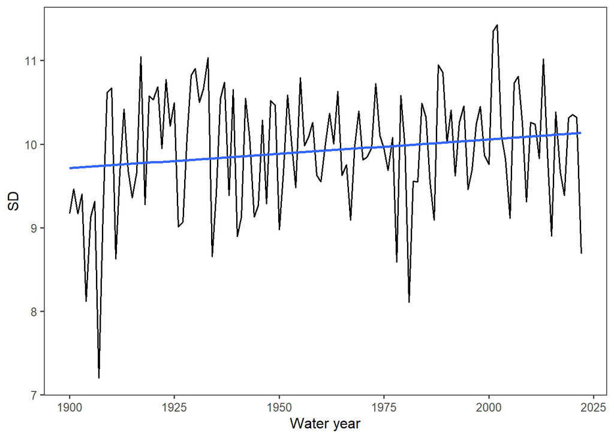

```r
ggplot(COOP_standard_dev_all, aes(x = waterYear, y = sd_2))+#, color = waterYear)) +
  geom_line(size= 0.7) +
  #geom_line(aes) +
  theme_few() +
  geom_smooth(method = "lm", se=FALSE) +
  ylab('SD') +
  xlab('Water year')
```

## Checking a random year from the timeseries.

```r
COOP_standard_dev_87 <- COOP_standard_dev %>%
  filter(waterYear == 1987) %>%
  group_by(waterYear) %>%
  mutate(resid_mean = mean(residual)) %>%
           mutate(sd_1 = residual-resid_mean)

COOP_standard_dev_87 <- COOP_standard_dev_87 %>%
  group_by(waterYear) %>%
  mutate(sd_2 = (((sum((sd_1)^2))/((sum(tabulate(COOP_standard_dev_87$waterDay)))-1)))^(0.5))

head(COOP_standard_dev_87$sd_2, 1)
```

```
## [1] 9.092295
```

*Looks good.*

# Summer temperature standard deviation

```r
COOP_standard_dev_all_summer <- COOP_standard_dev %>%
  filter(waterDay >= 244 & waterDay <= 335) %>% # this might be better off as daymonth rather than day of water year due to leap year
  group_by(waterYear) %>%
  mutate(nmbr = n())

COOP_standard_dev_all_summer <- COOP_standard_dev_all_summer %>%
  group_by(waterYear) %>%
  mutate(resid_mean = mean(residual)) %>%
  mutate(sd_1 = residual-resid_mean) %>%
  mutate(sd_2 = (((sum((sd_1)^2))/((nmbr-1))))^(0.5)) %>%
  distinct(sd_2, .keep_all = TRUE) %>%
   select(waterYear, sd_2)

COOP_standard_dev_all_summer %>%
  kable(.,'html') %>%
  kable_styling() %>%
  scroll_box(width='250px',height='500px')
```

| waterYear | sd_2 |
| --- | --- |
| 1900 | 2.430101 |
| 1901 | 3.402636 |
| 1902 | 2.538185 |
| 1903 | 3.184305 |
| 1904 | 2.262242 |
| 1905 | 1.963540 |
| 1906 | 2.487173 |
| 1907 | 2.202503 |
| 1908 | 2.998496 |
| 1909 | 2.685480 |
| 1910 | 2.556321 |
| 1911 | 2.104768 |
| 1912 | 2.971984 |
| 1913 | 2.612050 |
| 1914 | 2.429457 |
| 1915 | 2.944832 |
| 1916 | 3.037961 |
| 1917 | 3.023050 |
| 1918 | 2.467065 |
| 1919 | 3.270583 |
| 1920 | 2.975550 |
| 1921 | 2.337697 |
| 1922 | 2.301012 |
| 1923 | 2.459685 |
| 1924 | 2.444446 |
| 1925 | 2.856067 |
| 1926 | 2.466045 |
| 1927 | 2.900269 |
| 1928 | 2.941007 |
| 1929 | 3.301175 |

[output cut: 93 more lines]

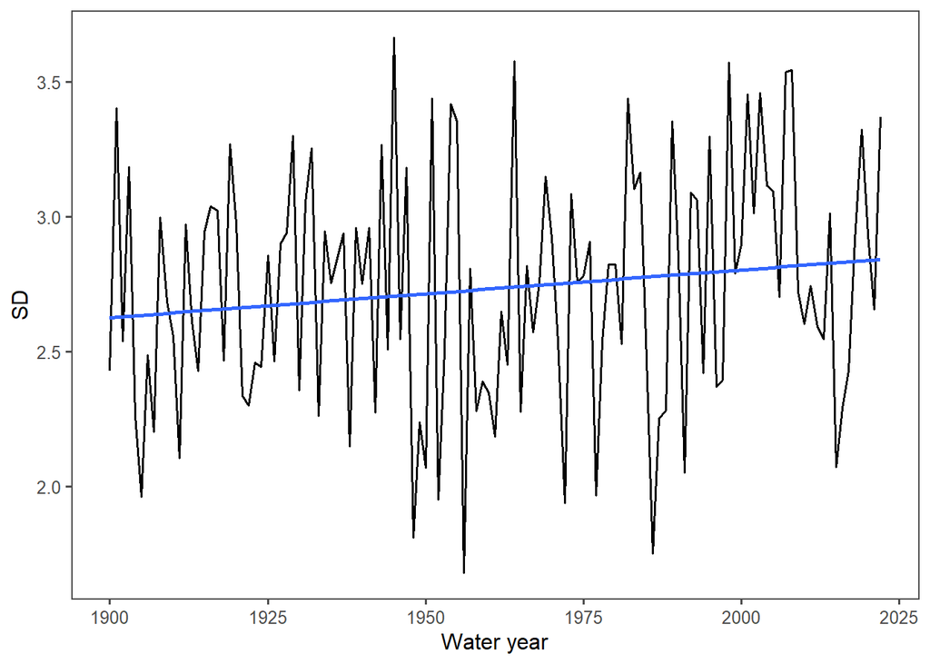

```r
ggplot(COOP_standard_dev_all_summer, aes(x = waterYear, y = sd_2))+#, color = waterYear)) +
  geom_line(size= 0.7) +
  #geom_line(aes) +
  theme_few() +
  geom_smooth(method = "lm", se=FALSE) +
  ylab('SD') +
  xlab('Water year')
```

## Mann-Kendall & Sen’s Slope

Summer standard deviations.

```r
sd_mk_summer <- mk.test(COOP_standard_dev_all_summer$sd_2)
print(sd_mk_summer)
```

```
##
##  Mann-Kendall trend test
##
## data:  COOP_standard_dev_all_summer$sd_2
## z = 1.5259, n = 123, p-value = 0.127
## alternative hypothesis: true S is not equal to 0
## sample estimates:
##            S         varS          tau
## 6.990000e+02 2.092503e+05 9.316273e-02
```

```r
sd_sens_summer <- sens.slope(COOP_standard_dev_all_summer$sd_2)
print(sd_sens_summer)
```

```
##
##  Sen's slope
##
## data:  COOP_standard_dev_all_summer$sd_2
## z = 1.5259, n = 123, p-value = 0.127
## alternative hypothesis: true z is not equal to 0
## 95 percent confidence interval:
##  -0.0005447118  0.0042348516
## sample estimates:
## Sen's slope
##  0.00184853
```

# Winter temperature standard deviation

```r
COOP_standard_dev_all_winter <- COOP_standard_dev %>%
  filter(waterDay >= 32 & waterDay <= 182) %>% # this might be better off as daymonth rather than day of water year due to leap year
  group_by(waterYear) %>%
  mutate(nmbr = n())

# Nope. This did some weird stuff with twice the observations.
# COOP_standard_dev_all_winter <- COOP_standard_dev %>%
#   filter(daymonth >= "01-11" & daymonth <= "31-03") %>%
#   group_by(waterYear) %>%
#   mutate(nmbr = n())


COOP_standard_dev_all_winter <- COOP_standard_dev_all_winter %>%
  group_by(waterYear) %>%
  mutate(resid_mean = mean(residual)) %>%
  mutate(sd_1 = residual-resid_mean) %>%
  mutate(sd_2 = (((sum((sd_1)^2))/((nmbr-1))))^(0.5)) %>%
  distinct(sd_2, .keep_all = TRUE) %>%
   select(waterYear, sd_2)

COOP_standard_dev_all_winter %>%
  kable(.,'html') %>%
  kable_styling() %>%
  scroll_box(width='250px',height='500px')
```

| waterYear | sd_2 |
| --- | --- |
| 1900 | 4.949540 |
| 1901 | 5.699325 |
| 1902 | 5.076412 |
| 1903 | 5.037521 |
| 1904 | 5.814624 |
| 1905 | 5.712387 |
| 1906 | 5.849447 |
| 1907 | 4.394361 |
| 1908 | 5.999769 |
| 1909 | 6.272830 |
| 1910 | 8.167094 |
| 1911 | 6.220118 |
| 1912 | 5.977724 |
| 1913 | 6.765554 |
| 1914 | 6.398980 |
| 1915 | 6.265197 |
| 1916 | 6.577823 |
| 1917 | 6.742992 |
| 1918 | 6.175213 |
| 1919 | 6.205188 |
| 1920 | 6.456513 |
| 1921 | 6.531154 |
| 1922 | 6.497864 |
| 1923 | 4.739331 |
| 1924 | 6.099856 |
| 1925 | 6.354407 |
| 1926 | 5.074319 |
| 1927 | 5.672765 |
| 1928 | 7.208769 |
| 1929 | 6.252479 |

[output cut: 93 more lines]

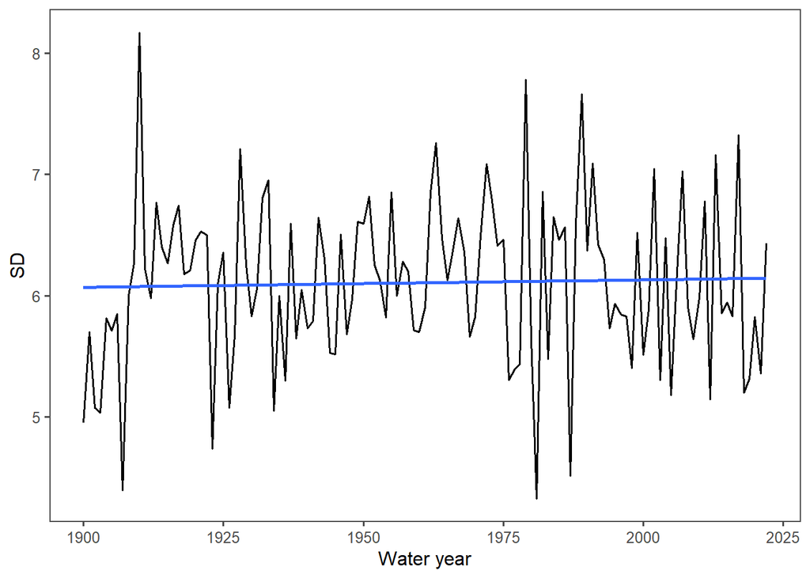

```r
ggplot(COOP_standard_dev_all_winter, aes(x = waterYear, y = sd_2))+#, color = waterYear)) +
  geom_line(size= 0.7) +
  #geom_line(aes) +
  theme_few() +
  geom_smooth(method = "lm", se=FALSE) +
  ylab('SD') +
  xlab('Water year')
```

## Mann-Kendall & Sen’s Slope

Winter standard deviations.

```r
sd_mk_winter <- mk.test(COOP_standard_dev_all_winter$sd_2)
print(sd_mk_winter)
```

```
##
##  Mann-Kendall trend test
##
## data:  COOP_standard_dev_all_winter$sd_2
## z = 0.2667, n = 123, p-value = 0.7897
## alternative hypothesis: true S is not equal to 0
## sample estimates:
##            S         varS          tau
## 1.230000e+02 2.092503e+05 1.639344e-02
```

```r
sd_sens_winter <- sens.slope(COOP_standard_dev_all_winter$sd_2)
print(sd_sens_winter)
```

```
##
##  Sen's slope
##
## data:  COOP_standard_dev_all_winter$sd_2
## z = 0.2667, n = 123, p-value = 0.7897
## alternative hypothesis: true z is not equal to 0
## 95 percent confidence interval:
##  -0.003272529  0.003920422
## sample estimates:
##  Sen's slope
## 0.0003806778
```

Smaller time increments might be useful….

# 1987 - 2021

In comparison to the Tower SNOTEL site:

```r
# I did this wrong- need to compare the 1987- 2021 time series without the mean of the 1900 - 2021 time series influencing the residuals.

#average water year temperature

COOP_yearly_wy_aver_87_21 <- coop_steamboat_clean %>%
  filter(waterYear >= 1987 & waterYear <= 2021) %>%
  group_by(waterYear) %>%
  mutate(aver_ann_temp = mean(avg_T_c))

#Average temperature by day for all water years:

COOP_daily_wy_aver_87_21 <- COOP_yearly_wy_aver_87_21 %>%
  group_by(daymonth) %>%
  mutate(aver_day_temp = mean(aver_ann_temp))

#average mean temperature by day for the period of record:

COOP_daily_wy_aver_87_21 <- COOP_daily_wy_aver_87_21 %>%
  group_by(daymonth) %>%
  mutate(all_ave_temp = mean(COOP_daily_wy_aver_87_21$aver_day_temp)) %>%
  group_by(waterYear) %>%
  mutate(nmbr = n())


COOP_standard_dev_87_21 <- COOP_daily_wy_aver_87_21 %>%
  group_by(waterYear) %>%
  mutate(residual = (all_ave_temp-aver_ann_temp)+avg_T_c-aver_day_temp) %>%
  mutate(deviation = abs(residual-lag(residual)))

COOP_standard_dev_87_21 <- COOP_standard_dev_87_21 %>%
  group_by(waterYear) %>%
  mutate(resid_mean = mean(residual)) %>%
  mutate(sd_1 = residual-resid_mean) %>%
  mutate(sd_2 = (((sum((sd_1)^2))/((nmbr-1))))^(0.5)) %>%
  distinct(sd_2, .keep_all = TRUE) %>%
   select(waterYear, sd_2)


COOP_standard_dev_87_21 %>%
  kable(.,'html') %>%
  kable_styling() %>%
  scroll_box(width='250px',height='500px')
```

| waterYear | sd_2 |
| --- | --- |
| 1987 | 9.102168 |
| 1988 | 10.958235 |
| 1989 | 10.863926 |
| 1990 | 10.023350 |
| 1991 | 10.418768 |
| 1992 | 9.630059 |
| 1993 | 10.268430 |
| 1994 | 10.466511 |
| 1995 | 9.467851 |
| 1996 | 9.706283 |
| 1997 | 10.248243 |
| 1998 | 10.461905 |
| 1999 | 9.873779 |
| 2000 | 9.769783 |
| 2001 | 11.360586 |
| 2002 | 11.435819 |
| 2003 | 10.114558 |
| 2004 | 9.833681 |
| 2005 | 9.123187 |
| 2006 | 10.735583 |
| 2007 | 10.818504 |
| 2008 | 10.266411 |
| 2009 | 9.317293 |
| 2010 | 10.270779 |
| 2011 | 10.245595 |
| 2012 | 9.836633 |
| 2013 | 11.024487 |
| 2014 | 9.892355 |
| 2015 | 8.911855 |
| 2016 | 10.397202 |
| 2017 | 9.675927 |
| 2018 | 9.395575 |
| 2019 | 10.325819 |
| 2020 | 10.362511 |
| 2021 | 10.332149 |

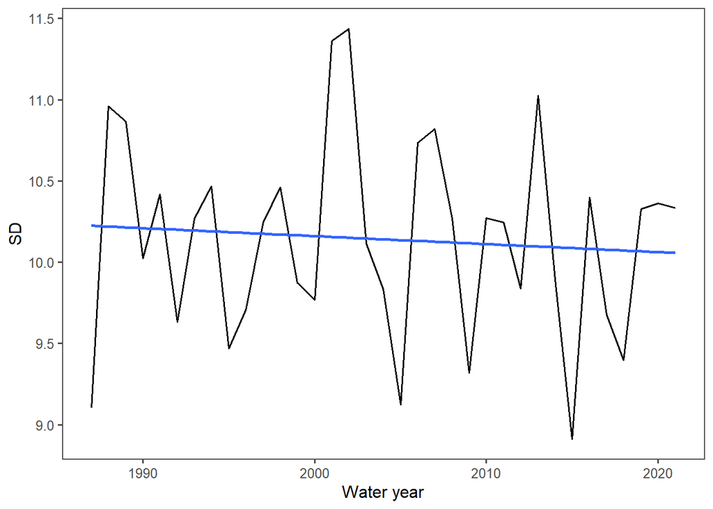

```r
ggplot(COOP_standard_dev_87_21, aes(x = waterYear, y = sd_2))+#, color = waterYear)) +
  geom_line(size= 0.7) +
  #geom_line(aes) +
  theme_few() +
  geom_smooth(method = "lm", se=FALSE) +
  ylab('SD') +
  xlab('Water year')
```

**SD for water years 1987 - 2021**

1987 - 2021 Mann-Kendall & Sen’s Slope

```r
sd_mk_87_21 <- mk.test(COOP_standard_dev_87_21$sd_2)
print(sd_mk_87_21)
```

```
##
##  Mann-Kendall trend test
##
## data:  COOP_standard_dev_87_21$sd_2
## z = -0.31243, n = 35, p-value = 0.7547
## alternative hypothesis: true S is not equal to 0
## sample estimates:
##             S          varS           tau
##  -23.00000000 4958.33333333   -0.03865546
```

```r
sd_sens_87_21 <- sens.slope(COOP_standard_dev_87_21$sd_2)
print(sd_sens_87_21)
```

```
##
##  Sen's slope
##
## data:  COOP_standard_dev_87_21$sd_2
## z = -0.31243, n = 35, p-value = 0.7547
## alternative hypothesis: true z is not equal to 0
## 95 percent confidence interval:
##  -0.02824511  0.01746551
## sample estimates:
##  Sen's slope
## -0.003150389
```

## Summer and Winter 87-21

# Summer temperature standard deviation

```r
# using the 1987- 2021 data frame

COOP_standard_dev_all_87_21_summer <- COOP_daily_wy_aver_87_21 %>%
  filter(waterDay >= 244 & waterDay <= 335) %>% # this might be better off as daymonth rather than day of water year due to leap year
  group_by(waterYear) %>%
  mutate(residual = (all_ave_temp-aver_ann_temp)+avg_T_c-aver_day_temp) %>%
  mutate(deviation = abs(residual-lag(residual))) %>%
  group_by(waterYear) %>%
  mutate(nmbr = n())

COOP_standard_dev_all_87_21_summer <- COOP_standard_dev_all_87_21_summer %>%
  group_by(waterYear) %>%
  mutate(resid_mean = mean(residual)) %>%
  mutate(sd_1 = residual-resid_mean) %>%
  mutate(sd_2 = (((sum((sd_1)^2))/((nmbr-1))))^(0.5)) %>%
  distinct(sd_2, .keep_all = TRUE) %>%
   select(waterYear, sd_2)

COOP_standard_dev_all_87_21_summer %>%
  kable(.,'html') %>%
  kable_styling() %>%
  scroll_box(width='250px',height='500px')
```

| waterYear | sd_2 |
| --- | --- |
| 1987 | 2.256401 |
| 1988 | 2.285152 |
| 1989 | 3.360473 |
| 1990 | 2.852068 |
| 1991 | 2.058611 |
| 1992 | 3.096955 |
| 1993 | 3.067035 |
| 1994 | 2.426131 |
| 1995 | 3.305683 |
| 1996 | 2.377386 |
| 1997 | 2.398553 |
| 1998 | 3.580276 |
| 1999 | 2.797057 |
| 2000 | 2.904944 |
| 2001 | 3.460685 |
| 2002 | 3.017018 |
| 2003 | 3.467162 |
| 2004 | 3.122014 |
| 2005 | 3.101184 |
| 2006 | 2.707708 |
| 2007 | 3.544183 |
| 2008 | 3.549712 |
| 2009 | 2.728170 |
| 2010 | 2.607813 |
| 2011 | 2.753046 |
| 2012 | 2.597680 |
| 2013 | 2.552035 |
| 2014 | 3.020503 |
| 2015 | 2.073783 |
| 2016 | 2.293315 |
| 2017 | 2.437804 |
| 2018 | 2.919615 |
| 2019 | 3.330728 |
| 2020 | 2.941152 |
| 2021 | 2.660758 |

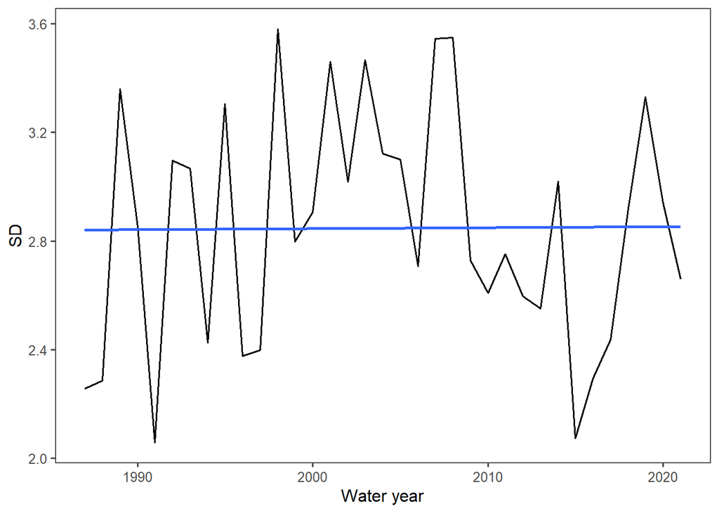

```r
ggplot(COOP_standard_dev_all_87_21_summer, aes(x = waterYear, y = sd_2))+#, color = waterYear)) +
  geom_line(size= 0.7) +
  #geom_line(aes) +
  theme_few() +
  geom_smooth(method = "lm", se=FALSE) +
  ylab('SD') +
  xlab('Water year')
```

**Summer season SD for water years 1987 - 2021**

## Mann-Kendall & Sen’s Slope

Summer 87-21 standard deviations.

```r
sd_mk_summer <- mk.test(COOP_standard_dev_all_87_21_summer$sd_2)
print(sd_mk_summer)
```

```
##
##  Mann-Kendall trend test
##
## data:  COOP_standard_dev_all_87_21_summer$sd_2
## z = 0.028403, n = 35, p-value = 0.9773
## alternative hypothesis: true S is not equal to 0
## sample estimates:
##            S         varS          tau
## 3.000000e+00 4.958333e+03 5.042017e-03
```

```r
sd_sens_summer <- sens.slope(COOP_standard_dev_all_summer$sd_2)
print(sd_sens_summer)
```

```
##
##  Sen's slope
##
## data:  COOP_standard_dev_all_summer$sd_2
## z = 1.5259, n = 123, p-value = 0.127
## alternative hypothesis: true z is not equal to 0
## 95 percent confidence interval:
##  -0.0005447118  0.0042348516
## sample estimates:
## Sen's slope
##  0.00184853
```

# Winter temperature standard deviation

```r
# using the 1987- 2021 data frame

COOP_standard_dev_all_87_21_winter <- COOP_daily_wy_aver_87_21 %>%
  filter(waterDay >= 32 & waterDay <= 182) %>% # this might be better off as daymonth rather than day of water year due to leap year
  group_by(waterYear) %>%
  mutate(residual = (all_ave_temp-aver_ann_temp)+avg_T_c-aver_day_temp) %>%
  mutate(deviation = abs(residual-lag(residual))) %>%
  group_by(waterYear) %>%
  mutate(nmbr = n())

COOP_standard_dev_all_87_21_winter <- COOP_standard_dev_all_87_21_winter %>%
  group_by(waterYear) %>%
  mutate(resid_mean = mean(residual)) %>%
  mutate(sd_1 = residual-resid_mean) %>%
  mutate(sd_2 = (((sum((sd_1)^2))/((nmbr-1))))^(0.5)) %>%
  distinct(sd_2, .keep_all = TRUE) %>%
   select(waterYear, sd_2)

COOP_standard_dev_all_87_21_winter %>%
  kable(.,'html') %>%
  kable_styling() %>%
  scroll_box(width='250px',height='500px')
```

| waterYear | sd_2 |
| --- | --- |
| 1987 | 4.514914 |
| 1988 | 6.586421 |
| 1989 | 7.659194 |
| 1990 | 6.368994 |
| 1991 | 7.092971 |
| 1992 | 6.422003 |
| 1993 | 6.297419 |
| 1994 | 5.731104 |
| 1995 | 5.934439 |
| 1996 | 5.843729 |
| 1997 | 5.830412 |
| 1998 | 5.402242 |
| 1999 | 6.520192 |
| 2000 | 5.512518 |
| 2001 | 5.891148 |
| 2002 | 7.045910 |
| 2003 | 5.302490 |
| 2004 | 6.473083 |
| 2005 | 5.182297 |
| 2006 | 6.100004 |
| 2007 | 7.024869 |
| 2008 | 5.906392 |
| 2009 | 5.640356 |
| 2010 | 5.983123 |
| 2011 | 6.774907 |
| 2012 | 5.146613 |
| 2013 | 7.155593 |
| 2014 | 5.857218 |
| 2015 | 5.946991 |
| 2016 | 5.825921 |
| 2017 | 7.325019 |
| 2018 | 5.197205 |
| 2019 | 5.312714 |
| 2020 | 5.825630 |
| 2021 | 5.355598 |

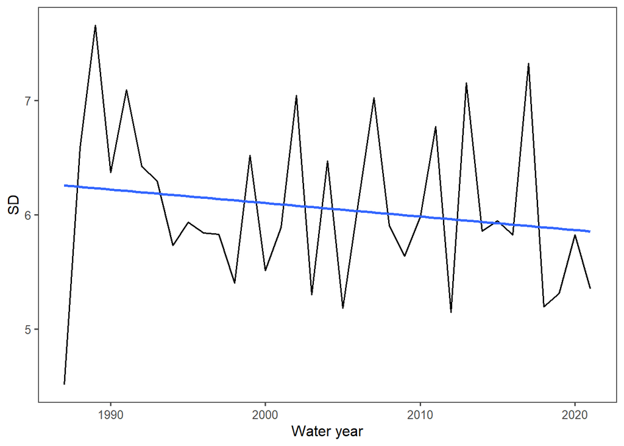

```r
ggplot(COOP_standard_dev_all_87_21_winter, aes(x = waterYear, y = sd_2))+#, color = waterYear)) +
  geom_line(size= 0.7) +
  #geom_line(aes) +
  theme_few() +
  geom_smooth(method = "lm", se=FALSE) +
  ylab('SD') +
  xlab('Water year')
```

**Winter season SD for water years 1987 - 2021**

## Mann-Kendall & Sen’s Slope

1987 - 2021 winter Mann-Kendall & Sen’s Slope

```r
sd_mk_87_21_winter <- mk.test(COOP_standard_dev_all_87_21_winter$sd_2)
print(sd_mk_87_21_winter)
```

```
##
##  Mann-Kendall trend test
##
## data:  COOP_standard_dev_all_87_21_winter$sd_2
## z = -1.4485, n = 35, p-value = 0.1475
## alternative hypothesis: true S is not equal to 0
## sample estimates:
##            S         varS          tau
## -103.0000000 4958.3333333   -0.1731092
```

```r
sd_sens_87_21_winter <- sens.slope(COOP_standard_dev_all_87_21_winter$sd_2)
print(sd_sens_87_21_winter)
```

```
##
##  Sen's slope
##
## data:  COOP_standard_dev_all_87_21_winter$sd_2
## z = -1.4485, n = 35, p-value = 0.1475
## alternative hypothesis: true z is not equal to 0
## 95 percent confidence interval:
##  -0.04110454  0.00690733
## sample estimates:
## Sen's slope
##   -0.018488
```

Neither the 1987 - 2021 as a whole, nor the seasonal time series demonstrate trends that are statistically significant.

# 1900-1915 minimum and maximum temperatures

Jan 7, 1913 had the lowest recorded temperature. This just looks at the max and min temperatures for that early part of the record.

```r
early_coop <- coop_steamboat_clean %>%
  filter(waterYear >= 1900 & waterYear <= 1915)

COOP_temp_min_xts <- xts(early_coop$min_T_c, order.by = early_coop$Date)

dygraph(COOP_temp_min_xts) %>%
  dyAxis("y", label = "Daily min temperature (°C)")
```

[interactive chart not shown]

*Daily minimum temperatures for water years 1900-1915*

```r
COOP_temp_max_xts <- xts(early_coop$max_T_c, order.by = early_coop$Date)

dygraph(COOP_temp_max_xts) %>%
  dyAxis("y", label = "Daily max temperature (°C)")
```

[interactive chart not shown]

# **By groups of decades**

## 1900-1930

```r
#average water year temperature

COOP_yearly_wy_aver_00_30 <- coop_steamboat_clean %>%
  filter(waterYear >= 1900 & waterYear <= 1930) %>%
  group_by(waterYear) %>%
  mutate(aver_ann_temp = mean(avg_T_c))

#Average temperature by day for all water years:

COOP_daily_wy_aver_00_30 <- COOP_yearly_wy_aver_00_30 %>%
  group_by(daymonth) %>%
  mutate(aver_day_temp = mean(aver_ann_temp))

#average mean temperature by day for the period of record:

COOP_daily_wy_aver_00_30 <- COOP_daily_wy_aver_00_30 %>%
  group_by(daymonth) %>%
  mutate(all_ave_temp = mean(COOP_daily_wy_aver_00_30$aver_day_temp)) %>%
  group_by(waterYear) %>%
  mutate(nmbr = n())


COOP_standard_dev_00_30 <- COOP_daily_wy_aver_00_30 %>%
  group_by(waterYear) %>%
  mutate(residual = (all_ave_temp-aver_ann_temp)+avg_T_c-aver_day_temp) %>%
  mutate(deviation = abs(residual-lag(residual)))

COOP_standard_dev_00_30 <- COOP_standard_dev_00_30 %>%
  group_by(waterYear) %>%
  mutate(resid_mean = mean(residual)) %>%
  mutate(sd_1 = residual-resid_mean) %>%
  mutate(sd_2 = (((sum((sd_1)^2))/((nmbr-1))))^(0.5)) %>%
  distinct(sd_2, .keep_all = TRUE) %>%
   select(waterYear, sd_2)


COOP_standard_dev_00_30 %>%
  kable(.,'html') %>%
  kable_styling() %>%
  scroll_box(width='250px',height='500px')
```

| waterYear | sd_2 |
| --- | --- |
| 1900 | 9.172777 |
| 1901 | 9.465044 |
| 1902 | 9.166949 |
| 1903 | 9.406211 |
| 1904 | 8.119386 |
| 1905 | 9.120375 |
| 1906 | 9.312666 |
| 1907 | 7.203400 |
| 1908 | 9.152628 |
| 1909 | 10.612372 |
| 1910 | 10.666030 |
| 1911 | 8.628190 |
| 1912 | 9.663498 |
| 1913 | 10.415428 |
| 1914 | 9.682533 |
| 1915 | 9.357693 |
| 1916 | 9.664717 |
| 1917 | 11.045154 |
| 1918 | 9.279629 |
| 1919 | 10.576288 |
| 1920 | 10.526100 |
| 1921 | 10.680241 |
| 1922 | 9.950811 |
| 1923 | 10.770524 |
| 1924 | 10.214913 |
| 1925 | 10.489292 |
| 1926 | 9.006430 |
| 1927 | 9.070481 |
| 1928 | 10.080921 |
| 1929 | 10.820353 |
| 1930 | 10.900484 |

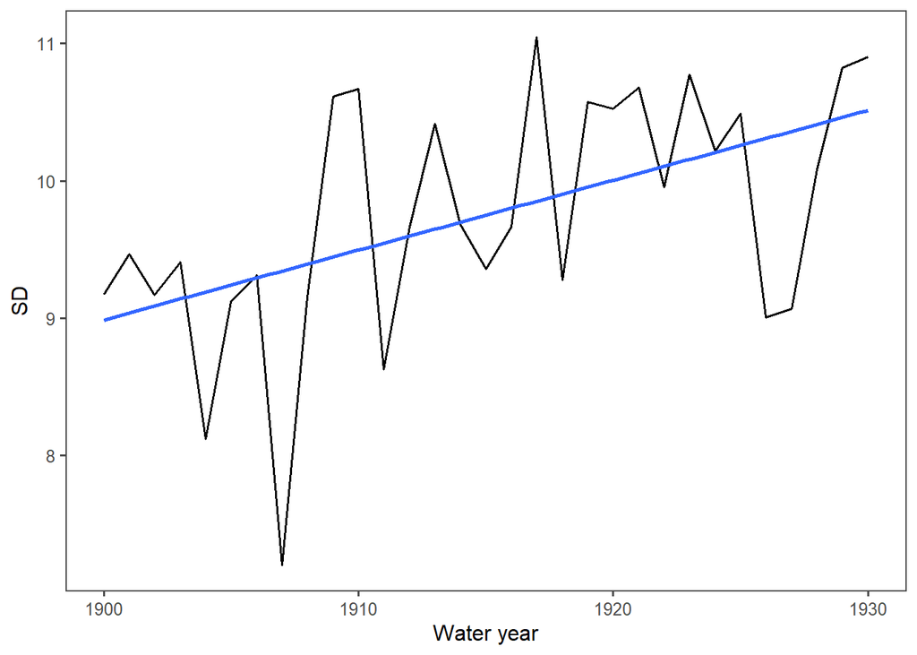

```r
ggplot(COOP_standard_dev_00_30, aes(x = waterYear, y = sd_2))+#, color = waterYear)) +
  geom_line(size= 0.7) +
  #geom_line(aes) +
  theme_few() +
  geom_smooth(method = "lm", se=FALSE) +
  ylab('SD') +
  xlab('Water year')
```

**SD for water years 1900 - 1930**

1900 - 1930 Mann-Kendall & Sen’s Slope

```r
sd_mk_00_30 <- mk.test(COOP_standard_dev_00_30$sd_2)
print(sd_mk_00_30)
```

```
##
##  Mann-Kendall trend test
##
## data:  COOP_standard_dev_00_30$sd_2
## z = 2.7194, n = 31, p-value = 0.00654
## alternative hypothesis: true S is not equal to 0
## sample estimates:
##            S         varS          tau
##  161.0000000 3461.6666667    0.3462366
```

```r
sd_sens_00_30 <- sens.slope(COOP_standard_dev_00_30$sd_2)
print(sd_sens_00_30)
```

```
##
##  Sen's slope
##
## data:  COOP_standard_dev_00_30$sd_2
## z = 2.7194, n = 31, p-value = 0.00654
## alternative hypothesis: true z is not equal to 0
## 95 percent confidence interval:
##  0.01672993 0.07781161
## sample estimates:
## Sen's slope
##  0.04840388
```

### Summer and Winter 00-30

Summer temperature standard deviation

```r
# using the 1900- 1930 data frame

COOP_standard_dev_all_00_30_summer <- COOP_daily_wy_aver_00_30 %>%
  filter(waterDay >= 244 & waterDay <= 335) %>% # this might be better off as daymonth rather than day of water year due to leap year
  group_by(waterYear) %>%
  mutate(residual = (all_ave_temp-aver_ann_temp)+avg_T_c-aver_day_temp) %>%
  mutate(deviation = abs(residual-lag(residual))) %>%
  group_by(waterYear) %>%
  mutate(nmbr = n())

COOP_standard_dev_all_00_30_summer <- COOP_standard_dev_all_00_30_summer %>%
  group_by(waterYear) %>%
  mutate(resid_mean = mean(residual)) %>%
  mutate(sd_1 = residual-resid_mean) %>%
  mutate(sd_2 = (((sum((sd_1)^2))/((nmbr-1))))^(0.5)) %>%
  distinct(sd_2, .keep_all = TRUE) %>%
   select(waterYear, sd_2)

COOP_standard_dev_all_00_30_summer %>%
  kable(.,'html') %>%
  kable_styling() %>%
  scroll_box(width='250px',height='500px')
```

| waterYear | sd_2 |
| --- | --- |
| 1900 | 2.431879 |
| 1901 | 3.410250 |
| 1902 | 2.541961 |
| 1903 | 3.192654 |
| 1904 | 2.269300 |
| 1905 | 1.969658 |
| 1906 | 2.494456 |
| 1907 | 2.212141 |
| 1908 | 3.006817 |
| 1909 | 2.692186 |
| 1910 | 2.561823 |
| 1911 | 2.108243 |
| 1912 | 2.978088 |
| 1913 | 2.618204 |
| 1914 | 2.436245 |
| 1915 | 2.951795 |
| 1916 | 3.045074 |
| 1917 | 3.029357 |
| 1918 | 2.465954 |
| 1919 | 3.276359 |
| 1920 | 2.979834 |
| 1921 | 2.339783 |
| 1922 | 2.305857 |
| 1923 | 2.466823 |
| 1924 | 2.449680 |
| 1925 | 2.861090 |
| 1926 | 2.469355 |
| 1927 | 2.902096 |
| 1928 | 2.946788 |
| 1929 | 3.308820 |
| 1930 | 2.363327 |

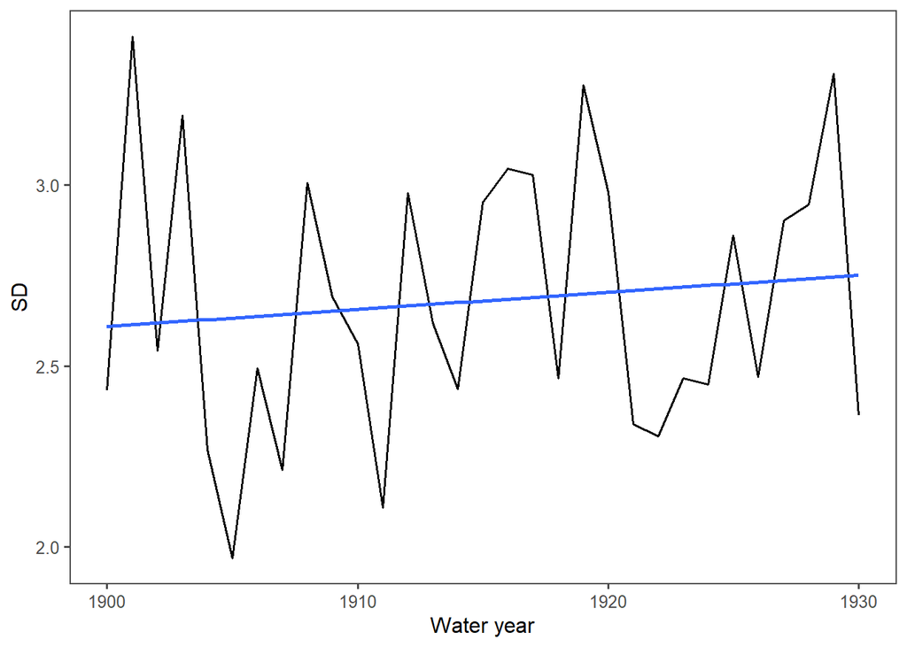

```r
ggplot(COOP_standard_dev_all_00_30_summer, aes(x = waterYear, y = sd_2))+#, color = waterYear)) +
  geom_line(size= 0.7) +
  #geom_line(aes) +
  theme_few() +
  geom_smooth(method = "lm", se=FALSE) +
  ylab('SD') +
  xlab('Water year')
```

**Summer season SD for water years 1900 - 1930**

Mann-Kendall & Sen’s Slope

Summer 00-30 standard deviations.

```r
sd_mk_00_30_summer <- mk.test(COOP_standard_dev_all_00_30_summer$sd_2)
print(sd_mk_00_30_summer)
```

```
##
##  Mann-Kendall trend test
##
## data:  COOP_standard_dev_all_00_30_summer$sd_2
## z = 0.54389, n = 31, p-value = 0.5865
## alternative hypothesis: true S is not equal to 0
## sample estimates:
##            S         varS          tau
## 3.300000e+01 3.461667e+03 7.096774e-02
```

```r
sd_sens_00_30_summer <- sens.slope(COOP_standard_dev_all_00_30_summer$sd_2)
print(sd_sens_00_30_summer)
```

```
##
##  Sen's slope
##
## data:  COOP_standard_dev_all_00_30_summer$sd_2
## z = 0.54389, n = 31, p-value = 0.5865
## alternative hypothesis: true z is not equal to 0
## 95 percent confidence interval:
##  -0.01031156  0.02309762
## sample estimates:
## Sen's slope
## 0.003397588
```

Winter temperature standard deviation

```r
# using the 00-30 data frame

COOP_standard_dev_all_00_30_winter <- COOP_daily_wy_aver_00_30 %>%
  filter(waterDay >= 32 & waterDay <= 182) %>% # this might be better off as daymonth rather than day of water year due to leap year
  group_by(waterYear) %>%
  mutate(residual = (all_ave_temp-aver_ann_temp)+avg_T_c-aver_day_temp) %>%
  mutate(deviation = abs(residual-lag(residual))) %>%
  group_by(waterYear) %>%
  mutate(nmbr = n())

COOP_standard_dev_all_00_30_winter <- COOP_standard_dev_all_00_30_winter %>%
  group_by(waterYear) %>%
  mutate(resid_mean = mean(residual)) %>%
  mutate(sd_1 = residual-resid_mean) %>%
  mutate(sd_2 = (((sum((sd_1)^2))/((nmbr-1))))^(0.5)) %>%
  distinct(sd_2, .keep_all = TRUE) %>%
   select(waterYear, sd_2)

COOP_standard_dev_all_00_30_winter %>%
  kable(.,'html') %>%
  kable_styling() %>%
  scroll_box(width='250px',height='500px')
```

| waterYear | sd_2 |
| --- | --- |
| 1900 | 4.949540 |
| 1901 | 5.705267 |
| 1902 | 5.080851 |
| 1903 | 5.046090 |
| 1904 | 5.817262 |
| 1905 | 5.712660 |
| 1906 | 5.845638 |
| 1907 | 4.391127 |
| 1908 | 6.008715 |
| 1909 | 6.269073 |
| 1910 | 8.165402 |
| 1911 | 6.225041 |
| 1912 | 5.970560 |
| 1913 | 6.768304 |
| 1914 | 6.404764 |
| 1915 | 6.267995 |
| 1916 | 6.579760 |
| 1917 | 6.747101 |
| 1918 | 6.187303 |
| 1919 | 6.206432 |
| 1920 | 6.453809 |
| 1921 | 6.531238 |
| 1922 | 6.510741 |
| 1923 | 4.749732 |
| 1924 | 6.105963 |
| 1925 | 6.354327 |
| 1926 | 5.084891 |
| 1927 | 5.678590 |
| 1928 | 7.209915 |
| 1929 | 6.254351 |
| 1930 | 5.832794 |

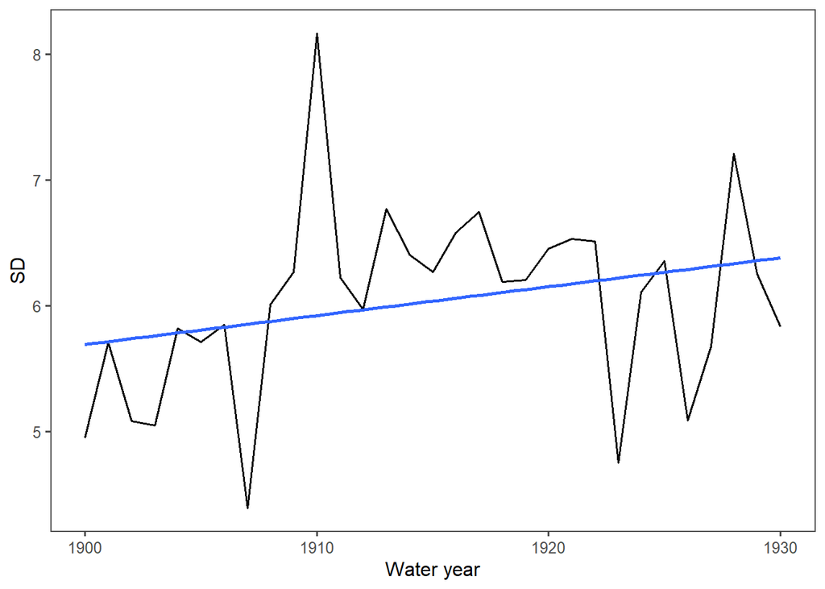

```r
ggplot(COOP_standard_dev_all_00_30_winter, aes(x = waterYear, y = sd_2))+#, color = waterYear)) +
  geom_line(size= 0.7) +
  #geom_line(aes) +
  theme_few() +
  geom_smooth(method = "lm", se=FALSE) +
  ylab('SD') +
  xlab('Water year')
```

**Winter season SD for water years 1900 - 1930**

Mann-Kendall & Sen’s Slope

1900 - 1930 winter Mann-Kendall & Sen’s Slope

```r
sd_mk_00_30_winter <- mk.test(COOP_standard_dev_all_00_30_winter$sd_2)
print(sd_mk_00_30_winter)
```

```
##
##  Mann-Kendall trend test
##
## data:  COOP_standard_dev_all_00_30_winter$sd_2
## z = 1.9376, n = 31, p-value = 0.05267
## alternative hypothesis: true S is not equal to 0
## sample estimates:
##            S         varS          tau
##  115.0000000 3461.6666667    0.2473118
```

```r
sd_sens_00_30_winter <- sens.slope(COOP_standard_dev_all_00_30_winter$sd_2)
print(sd_sens_00_30_winter)
```

```
##
##  Sen's slope
##
## data:  COOP_standard_dev_all_00_30_winter$sd_2
## z = 1.9376, n = 31, p-value = 0.05267
## alternative hypothesis: true z is not equal to 0
## 95 percent confidence interval:
##  -0.0001795691  0.0555335595
## sample estimates:
## Sen's slope
##  0.02807415
```

## 1931-1960

```r
#average water year temperature

COOP_yearly_wy_aver_31_60 <- coop_steamboat_clean %>%
  filter(waterYear >= 1931 & waterYear <= 1960) %>%
  group_by(waterYear) %>%
  mutate(aver_ann_temp = mean(avg_T_c))

#Average temperature by day for all water years:

COOP_daily_wy_aver_31_60 <- COOP_yearly_wy_aver_31_60 %>%
  group_by(daymonth) %>%
  mutate(aver_day_temp = mean(aver_ann_temp))

#average mean temperature by day for the period of record:

COOP_daily_wy_aver_31_60 <- COOP_daily_wy_aver_31_60 %>%
  group_by(daymonth) %>%
  mutate(all_ave_temp = mean(COOP_daily_wy_aver_31_60$aver_day_temp)) %>%
  group_by(waterYear) %>%
  mutate(nmbr = n())


COOP_standard_dev_31_60 <- COOP_daily_wy_aver_31_60 %>%
  group_by(waterYear) %>%
  mutate(residual = (all_ave_temp-aver_ann_temp)+avg_T_c-aver_day_temp) %>%
  mutate(deviation = abs(residual-lag(residual)))

COOP_standard_dev_31_60 <- COOP_standard_dev_31_60 %>%
  group_by(waterYear) %>%
  mutate(resid_mean = mean(residual)) %>%
  mutate(sd_1 = residual-resid_mean) %>%
  mutate(sd_2 = (((sum((sd_1)^2))/((nmbr-1))))^(0.5)) %>%
  distinct(sd_2, .keep_all = TRUE) %>%
   select(waterYear, sd_2)


COOP_standard_dev_31_60 %>%
  kable(.,'html') %>%
  kable_styling() %>%
  scroll_box(width='250px',height='500px')
```

| waterYear | sd_2 |
| --- | --- |
| 1931 | 10.511221 |
| 1932 | 10.671437 |
| 1933 | 11.042825 |
| 1934 | 8.663882 |
| 1935 | 9.419060 |
| 1936 | 10.551768 |
| 1937 | 10.747993 |
| 1938 | 9.396094 |
| 1939 | 10.660182 |
| 1940 | 8.904080 |
| 1941 | 9.140202 |
| 1942 | 10.555528 |
| 1943 | 10.090857 |
| 1944 | 9.140744 |
| 1945 | 9.273998 |
| 1946 | 10.297966 |
| 1947 | 9.297844 |
| 1948 | 10.529876 |
| 1949 | 10.476888 |
| 1950 | 8.984043 |
| 1951 | 9.668464 |
| 1952 | 10.595922 |
| 1953 | 10.010860 |
| 1954 | 9.486872 |
| 1955 | 10.802680 |
| 1956 | 9.992571 |
| 1957 | 10.096524 |
| 1958 | 10.270356 |
| 1959 | 9.634938 |
| 1960 | 9.562555 |

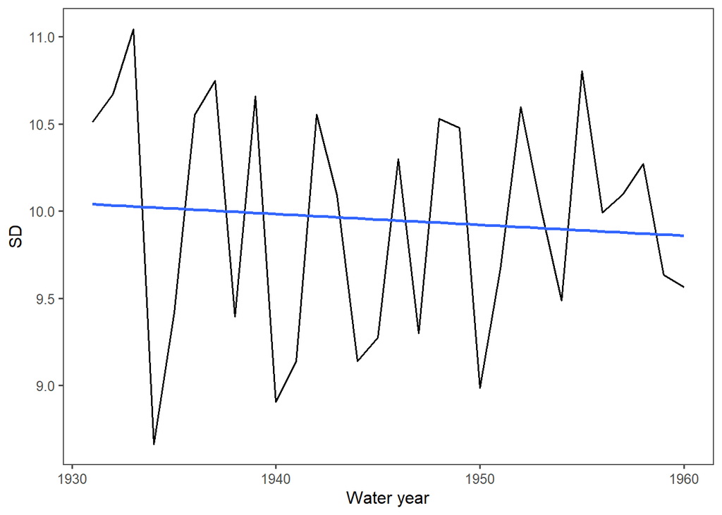

```r
ggplot(COOP_standard_dev_31_60, aes(x = waterYear, y = sd_2))+#, color = waterYear)) +
  geom_line(size= 0.7) +
  #geom_line(aes) +
  theme_few() +
  geom_smooth(method = "lm", se=FALSE) +
  ylab('SD') +
  xlab('Water year')
```

**SD for water years 1931 - 1960**

1931 - 1960 Mann-Kendall & Sen’s Slope

```r
sd_mk_31_60 <- mk.test(COOP_standard_dev_31_60$sd_2)
print(sd_mk_31_60)
```

```
##
##  Mann-Kendall trend test
##
## data:  COOP_standard_dev_31_60$sd_2
## z = -0.46387, n = 30, p-value = 0.6427
## alternative hypothesis: true S is not equal to 0
## sample estimates:
##             S          varS           tau
##  -27.00000000 3141.66666667   -0.06206897
```

```r
sd_sens_31_60 <- sens.slope(COOP_standard_dev_31_60$sd_2)
print(sd_sens_31_60)
```

```
##
##  Sen's slope
##
## data:  COOP_standard_dev_31_60$sd_2
## z = -0.46387, n = 30, p-value = 0.6427
## alternative hypothesis: true z is not equal to 0
## 95 percent confidence interval:
##  -0.03537111  0.02731004
## sample estimates:
##  Sen's slope
## -0.008847565
```

### Summer and Winter 31-60

Summer temperature standard deviation

```r
# using the 1931- 1960 data frame

COOP_standard_dev_all_31_60_summer <- COOP_daily_wy_aver_31_60 %>%
  filter(waterDay >= 244 & waterDay <= 335) %>% # this might be better off as daymonth rather than day of water year due to leap year
  group_by(waterYear) %>%
  mutate(residual = (all_ave_temp-aver_ann_temp)+avg_T_c-aver_day_temp) %>%
  mutate(deviation = abs(residual-lag(residual))) %>%
  group_by(waterYear) %>%
  mutate(nmbr = n())

COOP_standard_dev_all_31_60_summer <- COOP_standard_dev_all_31_60_summer %>%
  group_by(waterYear) %>%
  mutate(resid_mean = mean(residual)) %>%
  mutate(sd_1 = residual-resid_mean) %>%
  mutate(sd_2 = (((sum((sd_1)^2))/((nmbr-1))))^(0.5)) %>%
  distinct(sd_2, .keep_all = TRUE) %>%
   select(waterYear, sd_2)

COOP_standard_dev_all_31_60_summer %>%
  kable(.,'html') %>%
  kable_styling() %>%
  scroll_box(width='250px',height='500px')
```

| waterYear | sd_2 |
| --- | --- |
| 1931 | 3.059610 |
| 1932 | 3.262509 |
| 1933 | 2.265513 |
| 1934 | 2.954073 |
| 1935 | 2.760570 |
| 1936 | 2.850931 |
| 1937 | 2.945287 |
| 1938 | 2.154779 |
| 1939 | 2.967626 |
| 1940 | 2.756553 |
| 1941 | 2.965126 |
| 1942 | 2.284261 |
| 1943 | 3.273343 |
| 1944 | 2.515585 |
| 1945 | 3.672458 |
| 1946 | 2.554078 |
| 1947 | 3.191952 |
| 1948 | 1.816267 |
| 1949 | 2.247128 |
| 1950 | 2.077140 |
| 1951 | 3.447900 |
| 1952 | 1.957457 |
| 1953 | 2.507505 |
| 1954 | 3.423257 |
| 1955 | 3.363951 |
| 1956 | 1.685167 |
| 1957 | 2.815131 |
| 1958 | 2.286829 |
| 1959 | 2.394442 |
| 1960 | 2.353074 |

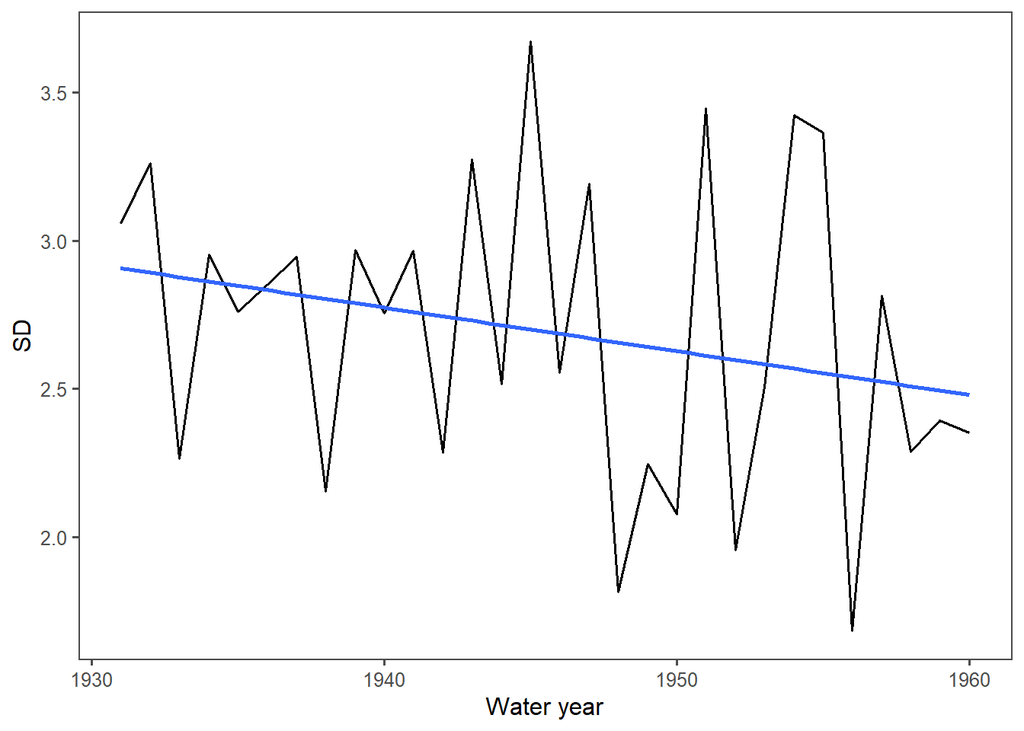

```r
ggplot(COOP_standard_dev_all_31_60_summer, aes(x = waterYear, y = sd_2))+#, color = waterYear)) +
  geom_line(size= 0.7) +
  #geom_line(aes) +
  theme_few() +
  geom_smooth(method = "lm", se=FALSE) +
  ylab('SD') +
  xlab('Water year')
```

**Summer season SD for water years 1931 - 1960**

Mann-Kendall & Sen’s Slope

Summer 31-60 standard deviations.

```r
sd_mk_31_60_summer <- mk.test(COOP_standard_dev_all_31_60_summer$sd_2)
print(sd_mk_31_60_summer)
```

```
##
##  Mann-Kendall trend test
##
## data:  COOP_standard_dev_all_31_60_summer$sd_2
## z = -1.2489, n = 30, p-value = 0.2117
## alternative hypothesis: true S is not equal to 0
## sample estimates:
##            S         varS          tau
##  -71.0000000 3141.6666667   -0.1632184
```

```r
sd_sens_31_60_summer <- sens.slope(COOP_standard_dev_all_31_60_summer$sd_2)
print(sd_sens_31_60_summer)
```

```
##
##  Sen's slope
##
## data:  COOP_standard_dev_all_31_60_summer$sd_2
## z = -1.2489, n = 30, p-value = 0.2117
## alternative hypothesis: true z is not equal to 0
## 95 percent confidence interval:
##  -0.037526136  0.008395392
## sample estimates:
## Sen's slope
## -0.01915759
```

Winter temperature standard deviation

```r
# using the 31-60 data frame

COOP_standard_dev_all_31_60_winter <- COOP_daily_wy_aver_31_60 %>%
  filter(waterDay >= 32 & waterDay <= 182) %>% # this might be better off as daymonth rather than day of water year due to leap year
  group_by(waterYear) %>%
  mutate(residual = (all_ave_temp-aver_ann_temp)+avg_T_c-aver_day_temp) %>%
  mutate(deviation = abs(residual-lag(residual))) %>%
  group_by(waterYear) %>%
  mutate(nmbr = n())

COOP_standard_dev_all_31_60_winter <- COOP_standard_dev_all_31_60_winter %>%
  group_by(waterYear) %>%
  mutate(resid_mean = mean(residual)) %>%
  mutate(sd_1 = residual-resid_mean) %>%
  mutate(sd_2 = (((sum((sd_1)^2))/((nmbr-1))))^(0.5)) %>%
  distinct(sd_2, .keep_all = TRUE) %>%
   select(waterYear, sd_2)

COOP_standard_dev_all_31_60_winter %>%
  kable(.,'html') %>%
  kable_styling() %>%
  scroll_box(width='250px',height='500px')
```

| waterYear | sd_2 |
| --- | --- |
| 1931 | 6.058059 |
| 1932 | 6.807918 |
| 1933 | 6.950811 |
| 1934 | 5.049704 |
| 1935 | 5.995266 |
| 1936 | 5.298087 |
| 1937 | 6.588829 |
| 1938 | 5.646021 |
| 1939 | 6.047402 |
| 1940 | 5.725247 |
| 1941 | 5.787883 |
| 1942 | 6.638044 |
| 1943 | 6.298906 |
| 1944 | 5.523354 |
| 1945 | 5.513925 |
| 1946 | 6.503188 |
| 1947 | 5.680125 |
| 1948 | 5.974457 |
| 1949 | 6.609061 |
| 1950 | 6.590044 |
| 1951 | 6.815037 |
| 1952 | 6.250117 |
| 1953 | 6.127065 |
| 1954 | 5.821476 |
| 1955 | 6.850402 |
| 1956 | 5.996948 |
| 1957 | 6.285852 |
| 1958 | 6.195907 |
| 1959 | 5.715565 |
| 1960 | 5.701816 |

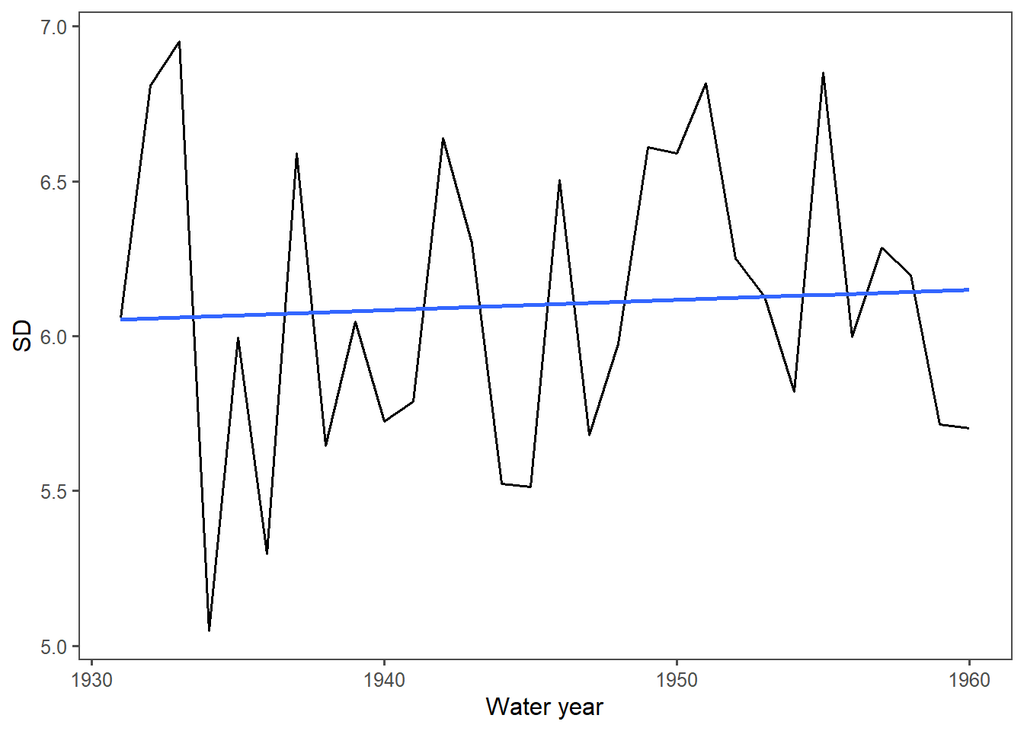

```r
ggplot(COOP_standard_dev_all_31_60_winter, aes(x = waterYear, y = sd_2))+#, color = waterYear)) +
  geom_line(size= 0.7) +
  #geom_line(aes) +
  theme_few() +
  geom_smooth(method = "lm", se=FALSE) +
  ylab('SD') +
  xlab('Water year')
```

**Winter season SD for water years 1931 - 1960**

Mann-Kendall & Sen’s Slope

1931 - 1960 winter Mann-Kendall & Sen’s Slope

```r
sd_mk_31_60_winter <- mk.test(COOP_standard_dev_all_31_60_winter$sd_2)
print(sd_mk_31_60_winter)
```

```
##
##  Mann-Kendall trend test
##
## data:  COOP_standard_dev_all_31_60_winter$sd_2
## z = 0.24977, n = 30, p-value = 0.8028
## alternative hypothesis: true S is not equal to 0
## sample estimates:
##            S         varS          tau
## 1.500000e+01 3.141667e+03 3.448276e-02
```

```r
sd_sens_31_60_winter <- sens.slope(COOP_standard_dev_all_31_60_winter$sd_2)
print(sd_sens_31_60_winter)
```

```
##
##  Sen's slope
##
## data:  COOP_standard_dev_all_31_60_winter$sd_2
## z = 0.24977, n = 30, p-value = 0.8028
## alternative hypothesis: true z is not equal to 0
## 95 percent confidence interval:
##  -0.02135937  0.03061119
## sample estimates:
## Sen's slope
## 0.002584094
```

## 1961-1990

```r
#average water year temperature

COOP_yearly_wy_aver_61_90 <- coop_steamboat_clean %>%
  filter(waterYear >= 1961 & waterYear <= 1990) %>%
  group_by(waterYear) %>%
  mutate(aver_ann_temp = mean(avg_T_c))

#Average temperature by day for all water years:

COOP_daily_wy_aver_61_90 <- COOP_yearly_wy_aver_61_90 %>%
  group_by(daymonth) %>%
  mutate(aver_day_temp = mean(aver_ann_temp))

#average mean temperature by day for the period of record:

COOP_daily_wy_aver_61_90 <- COOP_daily_wy_aver_61_90 %>%
  group_by(daymonth) %>%
  mutate(all_ave_temp = mean(COOP_daily_wy_aver_61_90$aver_day_temp)) %>%
  group_by(waterYear) %>%
  mutate(nmbr = n())


COOP_standard_dev_61_90 <- COOP_daily_wy_aver_61_90 %>%
  group_by(waterYear) %>%
  mutate(residual = (all_ave_temp-aver_ann_temp)+avg_T_c-aver_day_temp) %>%
  mutate(deviation = abs(residual-lag(residual)))

COOP_standard_dev_61_90 <- COOP_standard_dev_61_90 %>%
  group_by(waterYear) %>%
  mutate(resid_mean = mean(residual)) %>%
  mutate(sd_1 = residual-resid_mean) %>%
  mutate(sd_2 = (((sum((sd_1)^2))/((nmbr-1))))^(0.5)) %>%
  distinct(sd_2, .keep_all = TRUE) %>%
   select(waterYear, sd_2)


COOP_standard_dev_61_90 %>%
  kable(.,'html') %>%
  kable_styling() %>%
  scroll_box(width='250px',height='500px')
```

| waterYear | sd_2 |
| --- | --- |
| 1961 | 10.016655 |
| 1962 | 10.376306 |
| 1963 | 10.014053 |
| 1964 | 10.639743 |
| 1965 | 9.636484 |
| 1966 | 9.758675 |
| 1967 | 9.101637 |
| 1968 | 9.985828 |
| 1969 | 10.405528 |
| 1970 | 9.821744 |
| 1971 | 9.853406 |
| 1972 | 9.961296 |
| 1973 | 10.733000 |
| 1974 | 10.114182 |
| 1975 | 9.958972 |
| 1976 | 9.697961 |
| 1977 | 10.090668 |
| 1978 | 8.596534 |
| 1979 | 10.589989 |
| 1980 | 9.980066 |
| 1981 | 8.121120 |
| 1982 | 9.563224 |
| 1983 | 9.562256 |
| 1984 | 10.499678 |
| 1985 | 10.331049 |
| 1986 | 9.546770 |
| 1987 | 9.102168 |
| 1988 | 10.957979 |
| 1989 | 10.863926 |
| 1990 | 10.023350 |

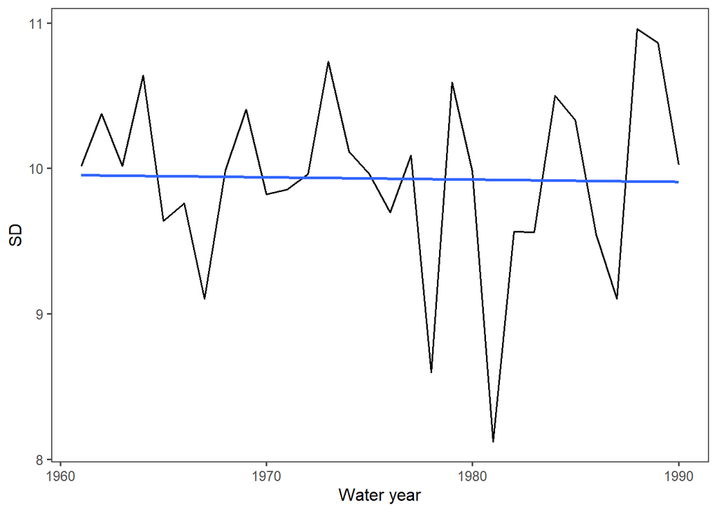

```r
ggplot(COOP_standard_dev_61_90, aes(x = waterYear, y = sd_2))+#, color = waterYear)) +
  geom_line(size= 0.7) +
  #geom_line(aes) +
  theme_few() +
  geom_smooth(method = "lm", se=FALSE) +
  ylab('SD') +
  xlab('Water year')
```

**SD for water years 1961 - 1990**

1961 - 1990 Mann-Kendall & Sen’s Slope

```r
sd_mk_61_90 <- mk.test(COOP_standard_dev_61_90$sd_2)
print(sd_mk_61_90)
```

```
##
##  Mann-Kendall trend test
##
## data:  COOP_standard_dev_61_90$sd_2
## z = -0.14273, n = 30, p-value = 0.8865
## alternative hypothesis: true S is not equal to 0
## sample estimates:
##             S          varS           tau
##   -9.00000000 3141.66666667   -0.02068966
```

```r
sd_sens_61_90 <- sens.slope(COOP_standard_dev_61_90$sd_2)
print(sd_sens_61_90)
```

```
##
##  Sen's slope
##
## data:  COOP_standard_dev_61_90$sd_2
## z = -0.14273, n = 30, p-value = 0.8865
## alternative hypothesis: true z is not equal to 0
## 95 percent confidence interval:
##  -0.02426245  0.02739368
## sample estimates:
##  Sen's slope
## -0.001925765
```

### Summer and Winter 61-90

Summer temperature standard deviation

```r
# using the 1961- 1990 data frame

COOP_standard_dev_all_61_90_summer <- COOP_daily_wy_aver_61_90 %>%
  filter(waterDay >= 244 & waterDay <= 335) %>% # this might be better off as daymonth rather than day of water year due to leap year
  group_by(waterYear) %>%
  mutate(residual = (all_ave_temp-aver_ann_temp)+avg_T_c-aver_day_temp) %>%
  mutate(deviation = abs(residual-lag(residual))) %>%
  group_by(waterYear) %>%
  mutate(nmbr = n())

COOP_standard_dev_all_61_90_summer <- COOP_standard_dev_all_61_90_summer %>%
  group_by(waterYear) %>%
  mutate(resid_mean = mean(residual)) %>%
  mutate(sd_1 = residual-resid_mean) %>%
  mutate(sd_2 = (((sum((sd_1)^2))/((nmbr-1))))^(0.5)) %>%
  distinct(sd_2, .keep_all = TRUE) %>%
   select(waterYear, sd_2)

COOP_standard_dev_all_61_90_summer %>%
  kable(.,'html') %>%
  kable_styling() %>%
  scroll_box(width='250px',height='500px')
```

| waterYear | sd_2 |
| --- | --- |
| 1961 | 2.192318 |
| 1962 | 2.653308 |
| 1963 | 2.459469 |
| 1964 | 3.584581 |
| 1965 | 2.284268 |
| 1966 | 2.825194 |
| 1967 | 2.581433 |
| 1968 | 2.759539 |
| 1969 | 3.158266 |
| 1970 | 2.929549 |
| 1971 | 2.543039 |
| 1972 | 1.942822 |
| 1973 | 3.091209 |
| 1974 | 2.759743 |
| 1975 | 2.790935 |
| 1976 | 2.916093 |
| 1977 | 1.972315 |
| 1978 | 2.543604 |
| 1979 | 2.830791 |
| 1980 | 2.829554 |
| 1981 | 2.532564 |
| 1982 | 3.446958 |
| 1983 | 3.110443 |
| 1984 | 3.172889 |
| 1985 | 2.475447 |
| 1986 | 1.756895 |
| 1987 | 2.256401 |
| 1988 | 2.285152 |
| 1989 | 3.360473 |
| 1990 | 2.852068 |

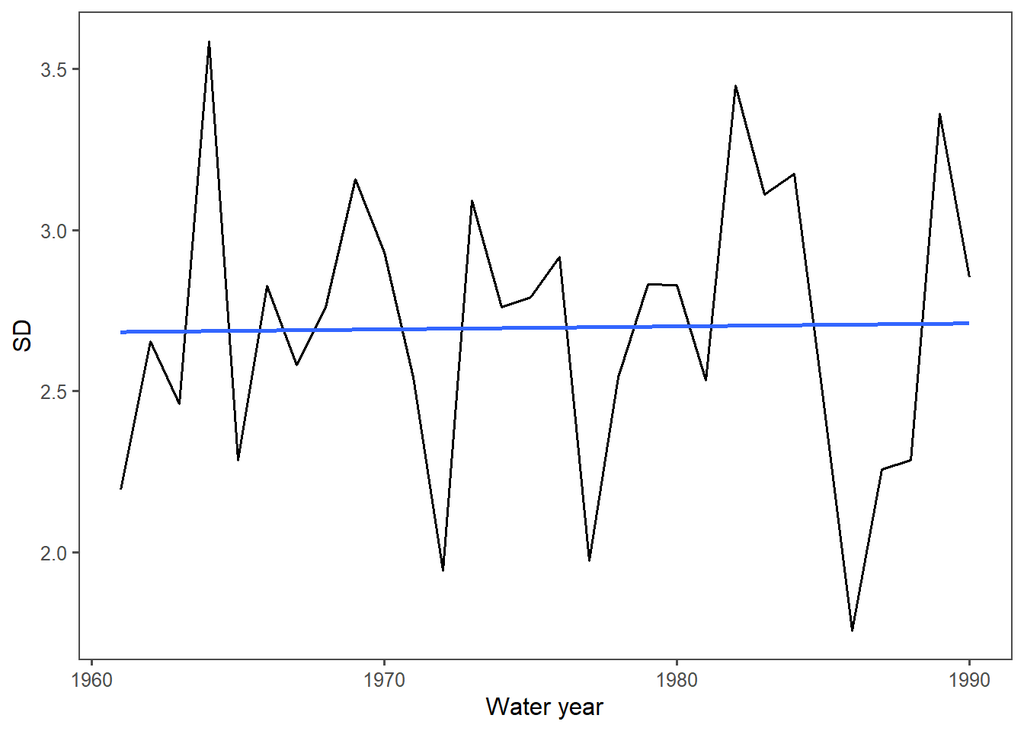

```r
ggplot(COOP_standard_dev_all_61_90_summer, aes(x = waterYear, y = sd_2))+#, color = waterYear)) +
  geom_line(size= 0.7) +
  #geom_line(aes) +
  theme_few() +
  geom_smooth(method = "lm", se=FALSE) +
  ylab('SD') +
  xlab('Water year')
```

**Summer season SD for water years 1961 - 1990**

Mann-Kendall & Sen’s Slope

Summer 61-90 standard deviations.

```r
sd_mk_61_90_summer <- mk.test(COOP_standard_dev_all_61_90_summer$sd_2)
print(sd_mk_61_90_summer)
```

```
##
##  Mann-Kendall trend test
##
## data:  COOP_standard_dev_all_61_90_summer$sd_2
## z = 0.49955, n = 30, p-value = 0.6174
## alternative hypothesis: true S is not equal to 0
## sample estimates:
##            S         varS          tau
## 2.900000e+01 3.141667e+03 6.666667e-02
```

```r
sd_sens_61_90_summer <- sens.slope(COOP_standard_dev_all_61_90_summer$sd_2)
print(sd_sens_61_90_summer)
```

```
##
##  Sen's slope
##
## data:  COOP_standard_dev_all_61_90_summer$sd_2
## z = 0.49955, n = 30, p-value = 0.6174
## alternative hypothesis: true z is not equal to 0
## 95 percent confidence interval:
##  -0.01741689  0.02583441
## sample estimates:
## Sen's slope
## 0.004075516
```

Winter temperature standard deviation

```r
# using the 61-90 data frame

COOP_standard_dev_all_61_90_winter <- COOP_daily_wy_aver_61_90 %>%
  filter(waterDay >= 32 & waterDay <= 182) %>% # this might be better off as daymonth rather than day of water year due to leap year
  group_by(waterYear) %>%
  mutate(residual = (all_ave_temp-aver_ann_temp)+avg_T_c-aver_day_temp) %>%
  mutate(deviation = abs(residual-lag(residual))) %>%
  group_by(waterYear) %>%
  mutate(nmbr = n())

COOP_standard_dev_all_61_90_winter <- COOP_standard_dev_all_61_90_winter %>%
  group_by(waterYear) %>%
  mutate(resid_mean = mean(residual)) %>%
  mutate(sd_1 = residual-resid_mean) %>%
  mutate(sd_2 = (((sum((sd_1)^2))/((nmbr-1))))^(0.5)) %>%
  distinct(sd_2, .keep_all = TRUE) %>%
   select(waterYear, sd_2)

COOP_standard_dev_all_61_90_winter %>%
  kable(.,'html') %>%
  kable_styling() %>%
  scroll_box(width='250px',height='500px')
```

| waterYear | sd_2 |
| --- | --- |
| 1961 | 5.902331 |
| 1962 | 6.850891 |
| 1963 | 7.255493 |
| 1964 | 6.467182 |
| 1965 | 6.124435 |
| 1966 | 6.366760 |
| 1967 | 6.636438 |
| 1968 | 6.361732 |
| 1969 | 5.661780 |
| 1970 | 5.824853 |
| 1971 | 6.495365 |
| 1972 | 7.085313 |
| 1973 | 6.780049 |
| 1974 | 6.407971 |
| 1975 | 6.460708 |
| 1976 | 5.303138 |
| 1977 | 5.386803 |
| 1978 | 5.430533 |
| 1979 | 7.778064 |
| 1980 | 5.636472 |
| 1981 | 4.326431 |
| 1982 | 6.854879 |
| 1983 | 5.477494 |
| 1984 | 6.646103 |
| 1985 | 6.458234 |
| 1986 | 6.568330 |
| 1987 | 4.514914 |
| 1988 | 6.588656 |
| 1989 | 7.659194 |
| 1990 | 6.368994 |

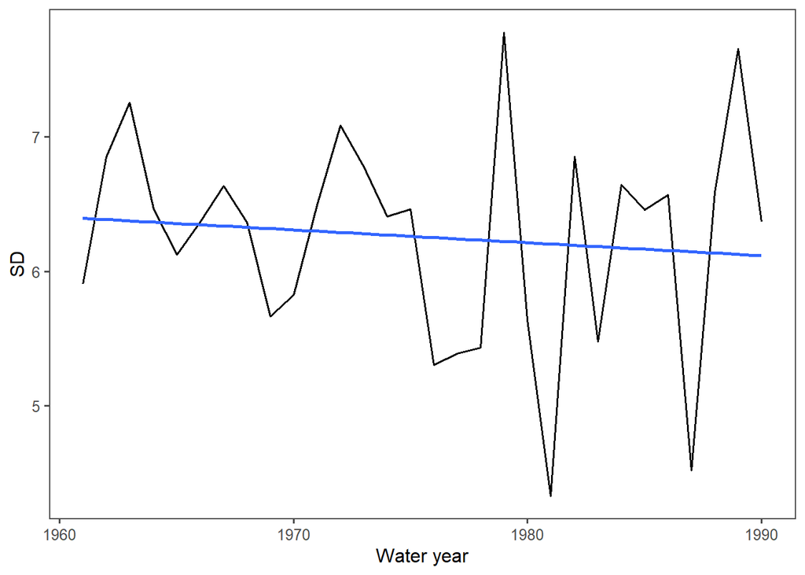

```r
ggplot(COOP_standard_dev_all_61_90_winter, aes(x = waterYear, y = sd_2))+#, color = waterYear)) +
  geom_line(size= 0.7) +
  #geom_line(aes) +
  theme_few() +
  geom_smooth(method = "lm", se=FALSE) +
  ylab('SD') +
  xlab('Water year')
```

**Winter season SD for water years 1961 - 1990**

Mann-Kendall & Sen’s Slope

1961 - 1990 winter Mann-Kendall & Sen’s Slope

```r
sd_mk_61_90_winter <- mk.test(COOP_standard_dev_all_61_90_winter$sd_2)
print(sd_mk_61_90_winter)
```

```
##
##  Mann-Kendall trend test
##
## data:  COOP_standard_dev_all_61_90_winter$sd_2
## z = -0.3925, n = 30, p-value = 0.6947
## alternative hypothesis: true S is not equal to 0
## sample estimates:
##             S          varS           tau
##  -23.00000000 3141.66666667   -0.05287356
```

```r
sd_sens_61_90_winter <- sens.slope(COOP_standard_dev_all_61_90_winter$sd_2)
print(sd_sens_61_90_winter)
```

```
##
##  Sen's slope
##
## data:  COOP_standard_dev_all_61_90_winter$sd_2
## z = -0.3925, n = 30, p-value = 0.6947
## alternative hypothesis: true z is not equal to 0
## 95 percent confidence interval:
##  -0.04437059  0.02381317
## sample estimates:
##  Sen's slope
## -0.006114251
```

```r
#average water year temperature

COOP_yearly_wy_aver_91_20 <- coop_steamboat_clean %>%
  filter(waterYear >= 1991 & waterYear <= 2020) %>%
  group_by(waterYear) %>%
  mutate(aver_ann_temp = mean(avg_T_c))

#Average temperature by day for all water years:

COOP_daily_wy_aver_91_20 <- COOP_yearly_wy_aver_91_20 %>%
  group_by(daymonth) %>%
  mutate(aver_day_temp = mean(aver_ann_temp))

#average mean temperature by day for the period of record:

COOP_daily_wy_aver_91_20 <- COOP_daily_wy_aver_91_20 %>%
  group_by(daymonth) %>%
  mutate(all_ave_temp = mean(COOP_daily_wy_aver_91_20$aver_day_temp)) %>%
  group_by(waterYear) %>%
  mutate(nmbr = n())


COOP_standard_dev_91_20 <- COOP_daily_wy_aver_61_90 %>%
  group_by(waterYear) %>%
  mutate(residual = (all_ave_temp-aver_ann_temp)+avg_T_c-aver_day_temp) %>%
  mutate(deviation = abs(residual-lag(residual)))

COOP_standard_dev_91_20 <- COOP_standard_dev_91_20 %>%
  group_by(waterYear) %>%
  mutate(resid_mean = mean(residual)) %>%
  mutate(sd_1 = residual-resid_mean) %>%
  mutate(sd_2 = (((sum((sd_1)^2))/((nmbr-1))))^(0.5)) %>%
  distinct(sd_2, .keep_all = TRUE) %>%
   select(waterYear, sd_2)


COOP_standard_dev_91_20 %>%
  kable(.,'html') %>%
  kable_styling() %>%
  scroll_box(width='250px',height='500px')
```

| waterYear | sd_2 |
| --- | --- |
| 1961 | 10.016655 |
| 1962 | 10.376306 |
| 1963 | 10.014053 |
| 1964 | 10.639743 |
| 1965 | 9.636484 |
| 1966 | 9.758675 |
| 1967 | 9.101637 |
| 1968 | 9.985828 |
| 1969 | 10.405528 |
| 1970 | 9.821744 |
| 1971 | 9.853406 |
| 1972 | 9.961296 |
| 1973 | 10.733000 |
| 1974 | 10.114182 |
| 1975 | 9.958972 |
| 1976 | 9.697961 |
| 1977 | 10.090668 |
| 1978 | 8.596534 |
| 1979 | 10.589989 |
| 1980 | 9.980066 |
| 1981 | 8.121120 |
| 1982 | 9.563224 |
| 1983 | 9.562256 |
| 1984 | 10.499678 |
| 1985 | 10.331049 |
| 1986 | 9.546770 |
| 1987 | 9.102168 |
| 1988 | 10.957979 |
| 1989 | 10.863926 |
| 1990 | 10.023350 |

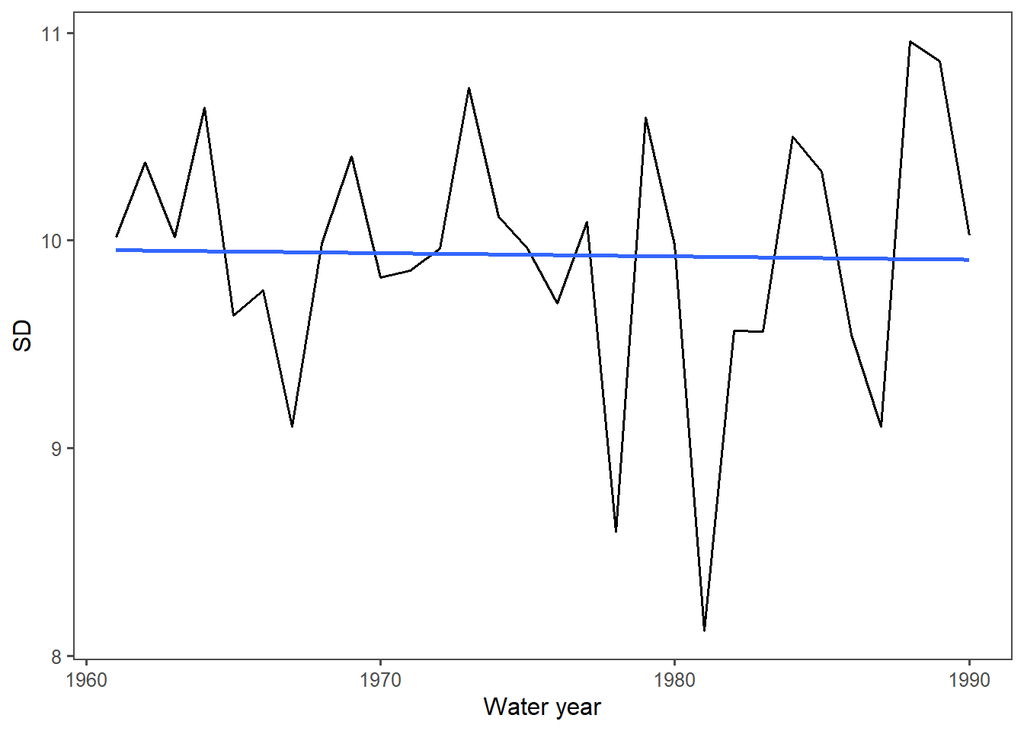

```r
ggplot(COOP_standard_dev_91_20, aes(x = waterYear, y = sd_2))+#, color = waterYear)) +
  geom_line(size= 0.7) +
  #geom_line(aes) +
  theme_few() +
  geom_smooth(method = "lm", se=FALSE) +
  ylab('SD') +
  xlab('Water year')
```

```r
sd_mk_91_20 <- mk.test(COOP_standard_dev_91_20$sd_2)
print(sd_mk_91_20)
```

```
##
##  Mann-Kendall trend test
##
## data:  COOP_standard_dev_91_20$sd_2
## z = -0.14273, n = 30, p-value = 0.8865
## alternative hypothesis: true S is not equal to 0
## sample estimates:
##             S          varS           tau
##   -9.00000000 3141.66666667   -0.02068966
```

```r
sd_sens_91_20 <- sens.slope(COOP_standard_dev_91_20$sd_2)
print(sd_sens_91_20)
```

```
##
##  Sen's slope
##
## data:  COOP_standard_dev_91_20$sd_2
## z = -0.14273, n = 30, p-value = 0.8865
## alternative hypothesis: true z is not equal to 0
## 95 percent confidence interval:
##  -0.02426245  0.02739368
## sample estimates:
##  Sen's slope
## -0.001925765
```

### Summer and Winter 91-20

Summer temperature standard deviation

```r
# using the 1991- 2020 data frame

COOP_standard_dev_all_91_20_summer <- COOP_daily_wy_aver_91_20 %>%
  filter(waterDay >= 244 & waterDay <= 335) %>% # this might be better off as daymonth rather than day of water year due to leap year
  group_by(waterYear) %>%
  mutate(residual = (all_ave_temp-aver_ann_temp)+avg_T_c-aver_day_temp) %>%
  mutate(deviation = abs(residual-lag(residual))) %>%
  group_by(waterYear) %>%
  mutate(nmbr = n())

COOP_standard_dev_all_91_20_summer <- COOP_standard_dev_all_91_20_summer %>%
  group_by(waterYear) %>%
  mutate(resid_mean = mean(residual)) %>%
  mutate(sd_1 = residual-resid_mean) %>%
  mutate(sd_2 = (((sum((sd_1)^2))/((nmbr-1))))^(0.5)) %>%
  distinct(sd_2, .keep_all = TRUE) %>%
   select(waterYear, sd_2)

COOP_standard_dev_all_91_20_summer %>%
  kable(.,'html') %>%
  kable_styling() %>%
  scroll_box(width='250px',height='500px')
```

| waterYear | sd_2 |
| --- | --- |
| 1991 | 2.058611 |
| 1992 | 3.096955 |
| 1993 | 3.067035 |
| 1994 | 2.426131 |
| 1995 | 3.305683 |
| 1996 | 2.377386 |
| 1997 | 2.398553 |
| 1998 | 3.580276 |
| 1999 | 2.797057 |
| 2000 | 2.904944 |
| 2001 | 3.460685 |
| 2002 | 3.017018 |
| 2003 | 3.467162 |
| 2004 | 3.122014 |
| 2005 | 3.101184 |
| 2006 | 2.707708 |
| 2007 | 3.544183 |
| 2008 | 3.549712 |
| 2009 | 2.728170 |
| 2010 | 2.607813 |
| 2011 | 2.753046 |
| 2012 | 2.597680 |
| 2013 | 2.552035 |
| 2014 | 3.020503 |
| 2015 | 2.073783 |
| 2016 | 2.293315 |
| 2017 | 2.437804 |
| 2018 | 2.919615 |
| 2019 | 3.330728 |
| 2020 | 2.941152 |

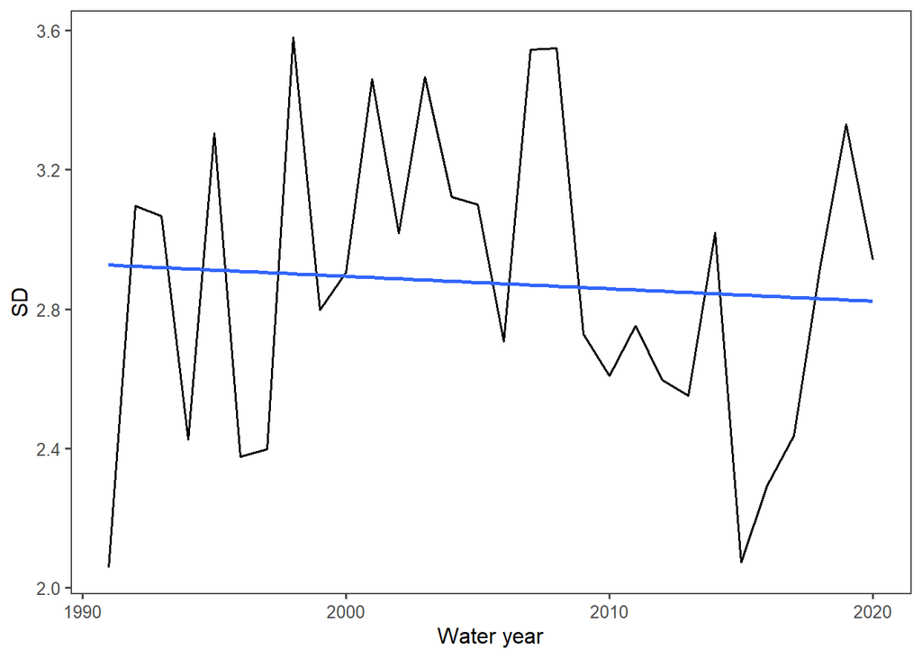

```r
ggplot(COOP_standard_dev_all_91_20_summer, aes(x = waterYear, y = sd_2))+#, color = waterYear)) +
  geom_line(size= 0.7) +
  #geom_line(aes) +
  theme_few() +
  geom_smooth(method = "lm", se=FALSE) +
  ylab('SD') +
  xlab('Water year')
```

**Summer season SD for water years 1991 - 2020**

Mann-Kendall & Sen’s Slope

Summer 91-20 standard deviations.

```r
sd_mk_91_20_summer <- mk.test(COOP_standard_dev_all_91_20_summer$sd_2)
print(sd_mk_91_20_summer)
```

```
##
##  Mann-Kendall trend test
##
## data:  COOP_standard_dev_all_91_20_summer$sd_2
## z = -0.42818, n = 30, p-value = 0.6685
## alternative hypothesis: true S is not equal to 0
## sample estimates:
##             S          varS           tau
##  -25.00000000 3141.66666667   -0.05747126
```

```r
sd_sens_91_20_summer <- sens.slope(COOP_standard_dev_all_91_20_summer$sd_2)
print(sd_sens_91_20_summer)
```

```
##
##  Sen's slope
##
## data:  COOP_standard_dev_all_91_20_summer$sd_2
## z = -0.42818, n = 30, p-value = 0.6685
## alternative hypothesis: true z is not equal to 0
## 95 percent confidence interval:
##  -0.02621794  0.01845355
## sample estimates:
##  Sen's slope
## -0.005896782
```

Winter temperature standard deviation

```r
# using the 91-20 data frame

COOP_standard_dev_all_91_20_winter <- COOP_daily_wy_aver_91_20 %>%
  filter(waterDay >= 32 & waterDay <= 182) %>% # this might be better off as daymonth rather than day of water year due to leap year
  group_by(waterYear) %>%
  mutate(residual = (all_ave_temp-aver_ann_temp)+avg_T_c-aver_day_temp) %>%
  mutate(deviation = abs(residual-lag(residual))) %>%
  group_by(waterYear) %>%
  mutate(nmbr = n())

COOP_standard_dev_all_91_20_winter <- COOP_standard_dev_all_91_20_winter %>%
  group_by(waterYear) %>%
  mutate(resid_mean = mean(residual)) %>%
  mutate(sd_1 = residual-resid_mean) %>%
  mutate(sd_2 = (((sum((sd_1)^2))/((nmbr-1))))^(0.5)) %>%
  distinct(sd_2, .keep_all = TRUE) %>%
   select(waterYear, sd_2)

COOP_standard_dev_all_91_20_winter %>%
  kable(.,'html') %>%
  kable_styling() %>%
  scroll_box(width='250px',height='500px')
```

| waterYear | sd_2 |
| --- | --- |
| 1991 | 7.092971 |
| 1992 | 6.421892 |
| 1993 | 6.297419 |
| 1994 | 5.731104 |
| 1995 | 5.934439 |
| 1996 | 5.843873 |
| 1997 | 5.830412 |
| 1998 | 5.402242 |
| 1999 | 6.520192 |
| 2000 | 5.512383 |
| 2001 | 5.891148 |
| 2002 | 7.045910 |
| 2003 | 5.302490 |
| 2004 | 6.473001 |
| 2005 | 5.182297 |
| 2006 | 6.100004 |
| 2007 | 7.024869 |
| 2008 | 5.906317 |
| 2009 | 5.640356 |
| 2010 | 5.983123 |
| 2011 | 6.774907 |
| 2012 | 5.146681 |
| 2013 | 7.155593 |
| 2014 | 5.857218 |
| 2015 | 5.946991 |
| 2016 | 5.825787 |
| 2017 | 7.325019 |
| 2018 | 5.197205 |
| 2019 | 5.312714 |
| 2020 | 5.825667 |

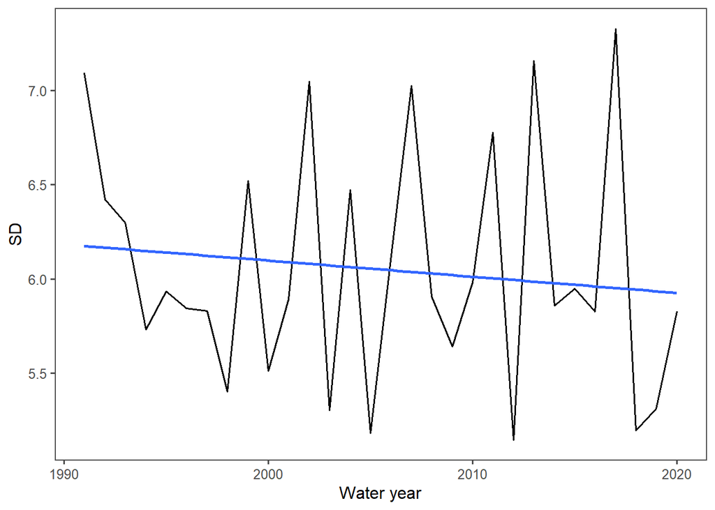

```r
ggplot(COOP_standard_dev_all_91_20_winter, aes(x = waterYear, y = sd_2))+#, color = waterYear)) +
  geom_line(size= 0.7) +
  #geom_line(aes) +
  theme_few() +
  geom_smooth(method = "lm", se=FALSE) +
  ylab('SD') +
  xlab('Water year')
```

**Winter season SD for water years 1991 - 2020**

Mann-Kendall & Sen’s Slope

1991 - 2020 winter Mann-Kendall & Sen’s Slope

```r
sd_mk_91_20_winter <- mk.test(COOP_standard_dev_all_91_20_winter$sd_2)
print(sd_mk_91_20_winter)
```

```
##
##  Mann-Kendall trend test
##
## data:  COOP_standard_dev_all_91_20_winter$sd_2
## z = -0.92773, n = 30, p-value = 0.3535
## alternative hypothesis: true S is not equal to 0
## sample estimates:
##            S         varS          tau
##  -53.0000000 3141.6666667   -0.1218391
```

```r
sd_sens_91_20_winter <- sens.slope(COOP_standard_dev_all_91_20_winter$sd_2)
print(sd_sens_91_20_winter)
```

```
##
##  Sen's slope
##
## data:  COOP_standard_dev_all_91_20_winter$sd_2
## z = -0.92773, n = 30, p-value = 0.3535
## alternative hypothesis: true z is not equal to 0
## 95 percent confidence interval:
##  -0.04082018  0.01404277
## sample estimates:
## Sen's slope
## -0.01025189
```

# Comparing Climate Normal means

(from 356:)

## 1991-2022

```r
COOP_yearly_wy_aver_1991_2022_CN <- coop_steamboat_clean %>%
  filter(waterYear >= 1991 & waterYear <= 2022) %>%
  group_by(waterYear) %>%
  mutate(aver_ann_temp = mean(avg_T_c))

#Average temperature by day for all water years:

COOP_daily_wy_aver_1991_2022_CN <- COOP_yearly_wy_aver_1991_2022_CN %>%
  group_by(daymonth) %>%
  mutate(aver_day_temp = mean(aver_ann_temp))

#average mean temperature by day for the period of record:

COOP_daily_wy_aver_1991_2022_CN <- COOP_daily_wy_aver_1991_2022_CN %>%
  group_by(daymonth) %>%
  mutate(all_ave_temp = mean(COOP_daily_wy_aver_1991_2022_CN$aver_day_temp)) %>%
  group_by(waterYear) %>%
  mutate(nmbr = n())
```

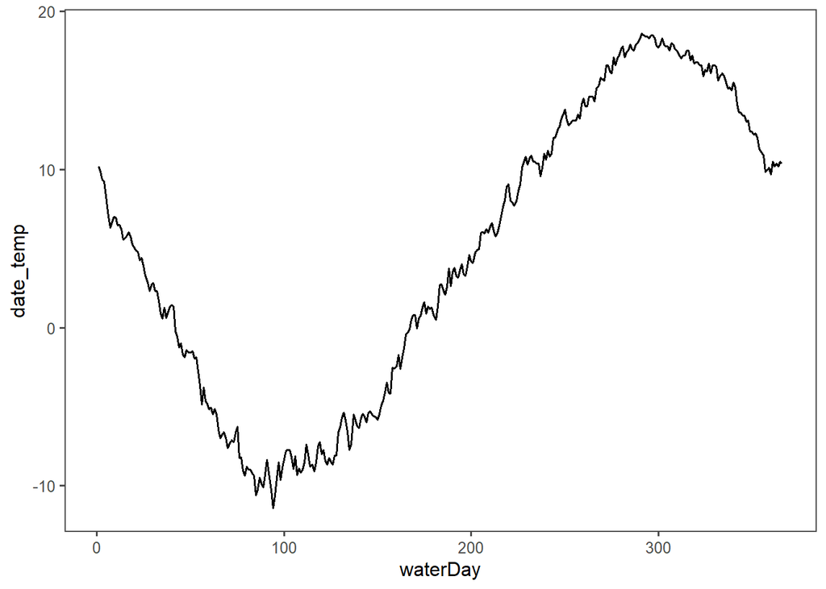

```r
COOP_daily_wy_aver_1991_2022_CN2 <- COOP_daily_wy_aver_1991_2022_CN %>%
  #filter(waterYear == "1987" | waterYear == "2021") %>%
  group_by(waterDay) %>%
  mutate(date_temp = mean(avg_T_c))%>%
  select(waterDay, date_temp) %>%
  distinct(waterDay, .keep_all = TRUE)

COOP_daily_wy_aver_1991_2022_CN2$date_temp <- signif(COOP_daily_wy_aver_1991_2022_CN2$date_temp,3) #reduce the sig figs

ggplot(COOP_daily_wy_aver_1991_2022_CN2, aes(x = waterDay, y = date_temp))+#, color = waterYear)) +
  geom_line(size= 0.7) +
  theme_few()
```

## 1961-1990

```r
COOP_yearly_wy_aver_1961_1990_CN <- coop_steamboat_clean %>%
  filter(waterYear >= 1961 & waterYear <= 1990) %>%
  group_by(waterYear) %>%
  mutate(aver_ann_temp = mean(avg_T_c))

#Average temperature by day for all water years:

COOP_daily_wy_aver_1961_1990_CN <- COOP_yearly_wy_aver_1961_1990_CN %>%
  group_by(daymonth) %>%
  mutate(aver_day_temp = mean(aver_ann_temp))

#average mean temperature by day for the period of record:

COOP_daily_wy_aver_1961_1990_CN <- COOP_daily_wy_aver_1961_1990_CN %>%
  group_by(daymonth) %>%
  mutate(all_ave_temp = mean(COOP_daily_wy_aver_1961_1990_CN$aver_day_temp)) %>%
  group_by(waterYear) %>%
  mutate(nmbr = n())
```

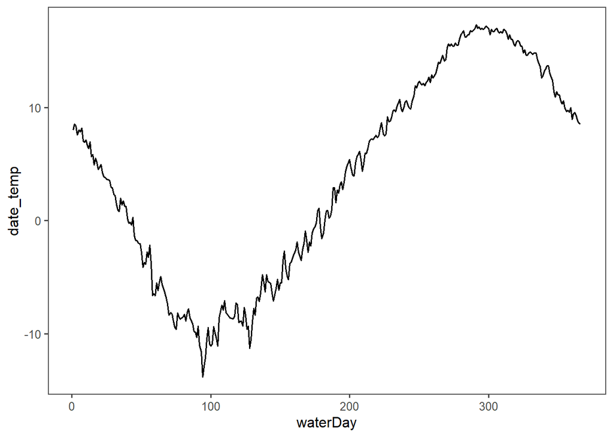

```r
COOP_daily_wy_aver_1961_1990_CN2 <- COOP_daily_wy_aver_1961_1990_CN %>%
  #filter(waterYear == "1987" | waterYear == "2021") %>%
  group_by(waterDay) %>%
  mutate(date_temp = mean(avg_T_c))%>%
  select(waterDay, date_temp) %>%
  distinct(waterDay, .keep_all = TRUE)

COOP_daily_wy_aver_1961_1990_CN2$date_temp <- signif(COOP_daily_wy_aver_1961_1990_CN2$date_temp,3) #reduce the sig figs

ggplot(COOP_daily_wy_aver_1961_1990_CN2, aes(x = waterDay, y = date_temp))+#, color = waterYear)) +
  geom_line(size= 0.7) +
  theme_few()
```

## 1931-1960

```r
COOP_yearly_wy_aver_1931_1960_CN <- coop_steamboat_clean %>%
  filter(waterYear >= 1931 & waterYear <= 1960) %>%
  group_by(waterYear) %>%
  mutate(aver_ann_temp = mean(avg_T_c))

#Average temperature by day for all water years:

COOP_daily_wy_aver_1931_1960_CN <- COOP_yearly_wy_aver_1931_1960_CN %>%
  group_by(daymonth) %>%
  mutate(aver_day_temp = mean(aver_ann_temp))

#average mean temperature by day for the period of record:

COOP_daily_wy_aver_1931_1960_CN <- COOP_daily_wy_aver_1931_1960_CN %>%
  group_by(daymonth) %>%
  mutate(all_ave_temp = mean(COOP_daily_wy_aver_1931_1960_CN$aver_day_temp)) %>%
  group_by(waterYear) %>%
  mutate(nmbr = n())
```

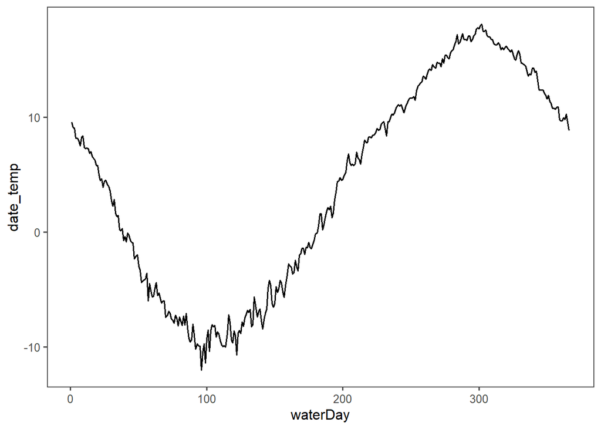

```r
COOP_daily_wy_aver_1931_1960_CN2 <- COOP_daily_wy_aver_1931_1960_CN %>%
  #filter(waterYear == "1987" | waterYear == "2021") %>%
  group_by(waterDay) %>%
  mutate(date_temp = mean(avg_T_c))%>%
  select(waterDay, date_temp)  %>%
  distinct(waterDay, .keep_all = TRUE)

COOP_daily_wy_aver_1931_1960_CN2$date_temp <- signif(COOP_daily_wy_aver_1931_1960_CN2$date_temp,3) #reduce the sig figs

ggplot(COOP_daily_wy_aver_1931_1960_CN2, aes(x = waterDay, y = date_temp))+#, color = waterYear)) +
  geom_line(size= 0.7) +
  theme_few()
```

## 1900-1930

```r
COOP_yearly_wy_aver_1901_1930_CN <- coop_steamboat_clean %>%
  filter(waterYear >= 1901 & waterYear <= 1930) %>%
  group_by(waterYear) %>%
  mutate(aver_ann_temp = mean(avg_T_c))

#Average temperature by day for all water years:

COOP_daily_wy_aver_1901_1930_CN <- COOP_yearly_wy_aver_1901_1930_CN %>%
  group_by(daymonth) %>%
  mutate(aver_day_temp = mean(aver_ann_temp))

#average mean temperature by day for the period of record:

COOP_daily_wy_aver_1901_1930_CN <- COOP_daily_wy_aver_1901_1930_CN %>%
  group_by(daymonth) %>%
  mutate(all_ave_temp = mean(COOP_daily_wy_aver_1901_1930_CN$aver_day_temp)) %>%
  group_by(waterYear) %>%
  mutate(nmbr = n())
```

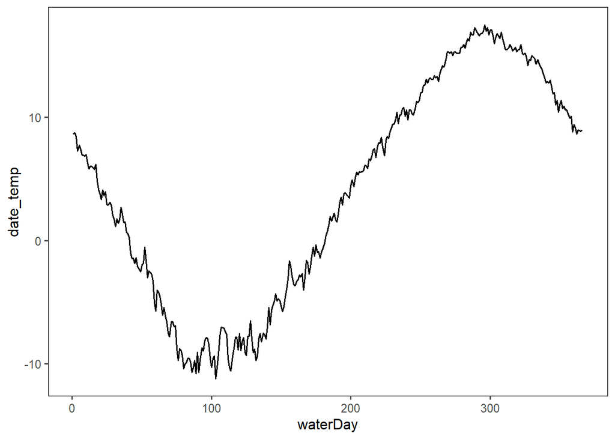

```r
COOP_daily_wy_aver_1901_1930_CN2 <- COOP_daily_wy_aver_1901_1930_CN %>%
  #filter(waterYear == "1987" | waterYear == "2021") %>%
  group_by(waterDay) %>%
  mutate(date_temp = mean(avg_T_c))%>%
  select(waterDay, date_temp) %>%
  distinct(waterDay, .keep_all = TRUE)


COOP_daily_wy_aver_1901_1930_CN2$date_temp <- signif(COOP_daily_wy_aver_1901_1930_CN2$date_temp,3) #reduce the sig figs

ggplot(COOP_daily_wy_aver_1901_1930_CN2, aes(x = waterDay, y = date_temp))+#, color = waterYear)) +
  geom_line(size= 0.7) +
  theme_few()
```

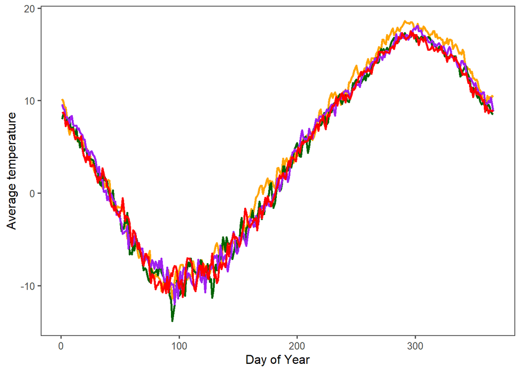

```r
climate_norm <- left_join(COOP_daily_wy_aver_1991_2022_CN2, COOP_daily_wy_aver_1961_1990_CN2, by= 'waterDay')

climate_norm <- left_join(climate_norm, COOP_daily_wy_aver_1931_1960_CN2, by= 'waterDay')

climate_norm <- left_join(climate_norm, COOP_daily_wy_aver_1901_1930_CN2, by= 'waterDay')

ggplot(climate_norm, aes(x=waterDay)) +
         #scale_size_manual(values=c("FALSE"=5,"TRUE"=8)) +
  #scale_color_manual(values=c("FALSE"='#CC0000',"TRUE"='black')) +
geom_line(aes(y = date_temp.x), size =1, color = "orange")+
  geom_line(aes(y = date_temp.y), size =1, color = "darkgreen")+
  geom_line(aes(y = date_temp.x.x), size =1, color = "purple")+
  geom_line(aes(y = date_temp.y.y), size =1, color= "red")+
  theme_few()+
  scale_colour_manual("", breaks=c("date_temp.x","date_temp.y","date_temp.x.x", "date_temp.y.y"), values=c("date_temp.x" = "orange", "date_temp.y" = "darkgreen", "date_temp.x.x" = "purple", "date_temp.y.y" = "red"))+
  xlab("Day of Year")+
  ylab("Average temperature")
```